# Supervised Learning - Foundations Project: ReCell

## Problem Statement

### Business Context

Buying and selling used phones and tablets used to be something that happened on a handful of online marketplace sites. But the used and refurbished device market has grown considerably over the past decade, and a new IDC (International Data Corporation) forecast predicts that the used phone market would be worth \$52.7bn by 2023 with a compound annual growth rate (CAGR) of 13.6% from 2018 to 2023. This growth can be attributed to an uptick in demand for used phones and tablets that offer considerable savings compared with new models.

Refurbished and used devices continue to provide cost-effective alternatives to both consumers and businesses that are looking to save money when purchasing one. There are plenty of other benefits associated with the used device market. Used and refurbished devices can be sold with warranties and can also be insured with proof of purchase. Third-party vendors/platforms, such as Verizon, Amazon, etc., provide attractive offers to customers for refurbished devices. Maximizing the longevity of devices through second-hand trade also reduces their environmental impact and helps in recycling and reducing waste. The impact of the COVID-19 outbreak may further boost this segment as consumers cut back on discretionary spending and buy phones and tablets only for immediate needs.

### Objective

The rising potential of this comparatively under-the-radar market fuels the need for an ML-based solution to develop a dynamic pricing strategy for used and refurbished devices. ReCell, a startup aiming to tap the potential in this market, has hired you as a data scientist. They want you to analyze the data provided and build a linear regression model to predict the price of a used phone/tablet and identify factors that significantly influence it.

### Data Description

The data contains the different attributes of used/refurbished phones and tablets. The data was collected in the year 2021. The detailed data dictionary is given below.

- brand_name: Name of manufacturing brand
- os: OS on which the device runs
- screen_size: Size of the screen in cm
- 4g: Whether 4G is available or not
- 5g: Whether 5G is available or not
- main_camera_mp: Resolution of the rear camera in megapixels
- selfie_camera_mp: Resolution of the front camera in megapixels
- int_memory: Amount of internal memory (ROM) in GB
- ram: Amount of RAM in GB
- battery: Energy capacity of the device battery in mAh
- weight: Weight of the device in grams
- release_year: Year when the device model was released
- days_used: Number of days the used/refurbished device has been used
- normalized_new_price: Normalized price of a new device of the same model in euros
- normalized_used_price: Normalized price of the used/refurbished device in euros

## Importing necessary libraries

```python
# Installing the libraries with the specified version.
# uncomment and run the following line if Google Colab is being used
# !pip install scikit-learn==1.2.2 seaborn==0.13.1 matplotlib==3.7.1 numpy==1.25.2 pandas==1.5.3 -q --user
```

```python
# Installing the libraries with the specified version.
# uncomment and run the following lines if Jupyter Notebook is being used
# !pip install scikit-learn==1.2.2 seaborn==0.11.1 matplotlib==3.3.4 numpy==1.24.3 pandas==1.5.2 -q --user
import numpy as np
import pandas as pd
import matplotlib.pyplot as plt
import seaborn as sns
from sklearn.model_selection import train_test_split
from sklearn.linear_model import LinearRegression
from sklearn.metrics import mean_absolute_error, mean_squared_error, r2_score
import statsmodels.api as sm
from statsmodels.stats.outliers_influence import variance_inflation_factor
```

```python
import warnings
warnings.filterwarnings("ignore", category=FutureWarning)
```

**Note**: *After running the above cell, kindly restart the notebook kernel and run all cells sequentially from the start again.*

```python
print("Restarting the kernel...")
```

```
Restarting the kernel...
```

## Loading the dataset

```python
df = pd.read_csv('/content/used_device_data.csv')
```

## Data Overview

- Observations
- Sanity checks

Displaying the first few rows of the dataset

```python
df.head()
```

|  | brand_name | os | screen_size | 4g | 5g | main_camera_mp | selfie_camera_mp | int_memory | ram | battery | weight | release_year | days_used | normalized_used_price | normalized_new_price |
| --- | --- | --- | --- | --- | --- | --- | --- | --- | --- | --- | --- | --- | --- | --- | --- |
| 0 | Honor | Android | 14.50 | yes | no | 13.0 | 5.0 | 64.0 | 3.0 | 3020.0 | 146.0 | 2020 | 127 | 4.307572 | 4.715100 |
| 1 | Honor | Android | 17.30 | yes | yes | 13.0 | 16.0 | 128.0 | 8.0 | 4300.0 | 213.0 | 2020 | 325 | 5.162097 | 5.519018 |
| 2 | Honor | Android | 16.69 | yes | yes | 13.0 | 8.0 | 128.0 | 8.0 | 4200.0 | 213.0 | 2020 | 162 | 5.111084 | 5.884631 |
| 3 | Honor | Android | 25.50 | yes | yes | 13.0 | 8.0 | 64.0 | 6.0 | 7250.0 | 480.0 | 2020 | 345 | 5.135387 | 5.630961 |
| 4 | Honor | Android | 15.32 | yes | no | 13.0 | 8.0 | 64.0 | 3.0 | 5000.0 | 185.0 | 2020 | 293 | 4.389995 | 4.947837 |

### Checking the shape of the dataset

```python
df.shape
```

```
(3454, 15)
```

### Checking the data types of the columns for the dataset

```python
df.info()
```

```
<class 'pandas.core.frame.DataFrame'>
RangeIndex: 3454 entries, 0 to 3453
Data columns (total 15 columns):
 #   Column                 Non-Null Count  Dtype
---  ------                 --------------  -----
 0   brand_name             3454 non-null   object
 1   os                     3454 non-null   object
 2   screen_size            3454 non-null   float64
 3   4g                     3454 non-null   object
 4   5g                     3454 non-null   object
 5   main_camera_mp         3275 non-null   float64
 6   selfie_camera_mp       3452 non-null   float64
 7   int_memory             3450 non-null   float64
 8   ram                    3450 non-null   float64
 9   battery                3448 non-null   float64
 10  weight                 3447 non-null   float64
 11  release_year           3454 non-null   int64
 12  days_used              3454 non-null   int64
 13  normalized_used_price  3454 non-null   float64
 14  normalized_new_price   3454 non-null   float64
dtypes: float64(9), int64(2), object(4)
memory usage: 404.9+ KB
```

### Statistical summary of the dataset

```python
df.describe()
```

|  | screen_size | main_camera_mp | selfie_camera_mp | int_memory | ram | battery | weight | release_year | days_used | normalized_used_price | normalized_new_price |
| --- | --- | --- | --- | --- | --- | --- | --- | --- | --- | --- | --- |
| count | 3454.000000 | 3275.000000 | 3452.000000 | 3450.000000 | 3450.000000 | 3448.000000 | 3447.000000 | 3454.000000 | 3454.000000 | 3454.000000 | 3454.000000 |
| mean | 13.713115 | 9.460208 | 6.554229 | 54.573099 | 4.036122 | 3133.402697 | 182.751871 | 2015.965258 | 674.869716 | 4.364712 | 5.233107 |
| std | 3.805280 | 4.815461 | 6.970372 | 84.972371 | 1.365105 | 1299.682844 | 88.413228 | 2.298455 | 248.580166 | 0.588914 | 0.683637 |
| min | 5.080000 | 0.080000 | 0.000000 | 0.010000 | 0.020000 | 500.000000 | 69.000000 | 2013.000000 | 91.000000 | 1.536867 | 2.901422 |
| 25% | 12.700000 | 5.000000 | 2.000000 | 16.000000 | 4.000000 | 2100.000000 | 142.000000 | 2014.000000 | 533.500000 | 4.033931 | 4.790342 |
| 50% | 12.830000 | 8.000000 | 5.000000 | 32.000000 | 4.000000 | 3000.000000 | 160.000000 | 2015.500000 | 690.500000 | 4.405133 | 5.245892 |
| 75% | 15.340000 | 13.000000 | 8.000000 | 64.000000 | 4.000000 | 4000.000000 | 185.000000 | 2018.000000 | 868.750000 | 4.755700 | 5.673718 |
| max | 30.710000 | 48.000000 | 32.000000 | 1024.000000 | 12.000000 | 9720.000000 | 855.000000 | 2020.000000 | 1094.000000 | 6.619433 | 7.847841 |

### Checking for duplicate values

```python
df.duplicated().sum()
```

```
np.int64(0)
```

### Checking for missing values

```python
df.isnull().sum()
```

|  | 0 |
| --- | --- |
| brand_name | 0 |
| os | 0 |
| screen_size | 0 |
| 4g | 0 |
| 5g | 0 |
| main_camera_mp | 179 |
| selfie_camera_mp | 2 |
| int_memory | 4 |
| ram | 4 |
| battery | 6 |
| weight | 7 |
| release_year | 0 |
| days_used | 0 |
| normalized_used_price | 0 |
| normalized_new_price | 0 |

**dtype:** int64

```python
df = df.copy()
```

## Exploratory Data Analysis (EDA)

- EDA is an important part of any project involving data.
- It is important to investigate and understand the data better before building a model with it.
- A few questions have been mentioned below which will help you approach the analysis in the right manner and generate insights from the data.
- A thorough analysis of the data, in addition to the questions mentioned below, should be done.

**Questions**:

1. What does the distribution of normalized used device prices look like?
2. What percentage of the used device market is dominated by Android devices?
3. The amount of RAM is important for the smooth functioning of a device. How does the amount of RAM vary with the brand?
4. A large battery often increases a device's weight, making it feel uncomfortable in the hands. How does the weight vary for phones and tablets offering large batteries (more than 4500 mAh)?
5. Bigger screens are desirable for entertainment purposes as they offer a better viewing experience. How many phones and tablets are available across different brands with a screen size larger than 6 inches?
6. A lot of devices nowadays offer great selfie cameras, allowing us to capture our favorite moments with loved ones. What is the distribution of devices offering greater than 8MP selfie cameras across brands?
7. Which attributes are highly correlated with the normalized price of a used device?

### Univariate Analysis

the distribution of normalized_used_device prices

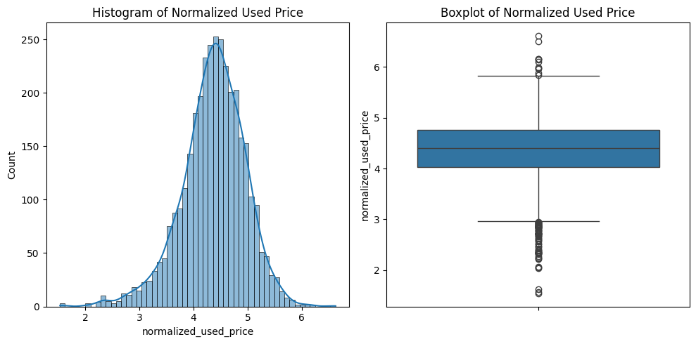

```python
# Plotting histogram and boxplot for normalized_used_price
plt.figure(figsize=(10, 5))

plt.subplot(1, 2, 1)
sns.histplot(df['normalized_used_price'], kde=True)
plt.title('Histogram of Normalized Used Price')

plt.subplot(1, 2, 2)
sns.boxplot(y=df['normalized_used_price'])
plt.title('Boxplot of Normalized Used Price')

plt.tight_layout()
plt.show()
```

normalized_new_price

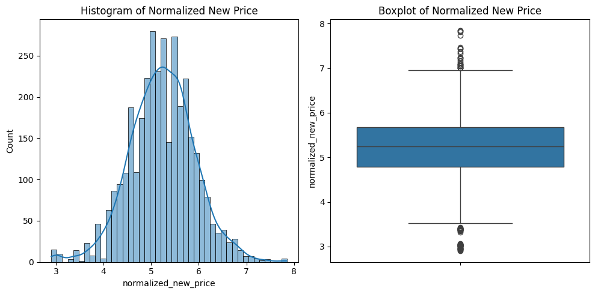

```python
# Plotting histogram and boxplot for normalized_new_price
plt.figure(figsize=(10, 5))

plt.subplot(1, 2, 1)
sns.histplot(df['normalized_new_price'], kde=True)
plt.title('Histogram of Normalized New Price')

plt.subplot(1, 2, 2)
sns.boxplot(y=df['normalized_new_price'])
plt.title('Boxplot of Normalized New Price')

plt.tight_layout()
plt.show()
```

screen_size

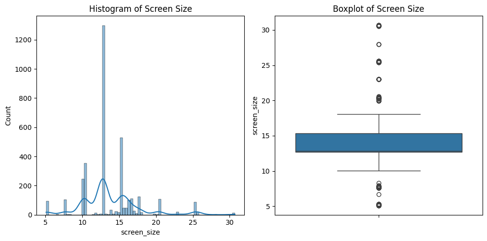

```python
# Plotting histogram and boxplot for screen_size
plt.figure(figsize=(10, 5))

plt.subplot(1, 2, 1)
sns.histplot(df['screen_size'], kde=True)
plt.title('Histogram of Screen Size')

plt.subplot(1, 2, 2)
sns.boxplot(y=df['screen_size'])
plt.title('Boxplot of Screen Size')

plt.tight_layout()
plt.show()
```

**`main_camera_mp`**

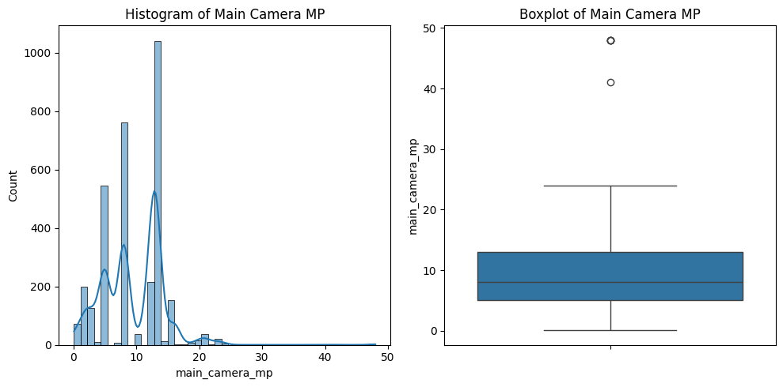

```python
# Plotting histogram and boxplot for main_camera_mp
plt.figure(figsize=(10, 5))

plt.subplot(1, 2, 1)
sns.histplot(df['main_camera_mp'], kde=True)
plt.title('Histogram of Main Camera MP')

plt.subplot(1, 2, 2)
sns.boxplot(y=df['main_camera_mp'])
plt.title('Boxplot of Main Camera MP')

plt.tight_layout()
plt.show()
```

selfie_camera_mp

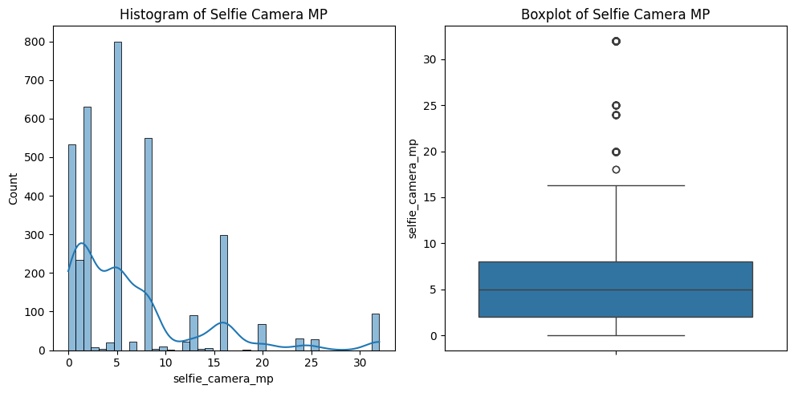

```python
# Plotting histogram and boxplot for selfie_camera_mp
plt.figure(figsize=(10, 5))

plt.subplot(1, 2, 1)
sns.histplot(df['selfie_camera_mp'], kde=True)
plt.title('Histogram of Selfie Camera MP')

plt.subplot(1, 2, 2)
sns.boxplot(y=df['selfie_camera_mp'])
plt.title('Boxplot of Selfie Camera MP')

plt.tight_layout()
plt.show()
```

int_memory

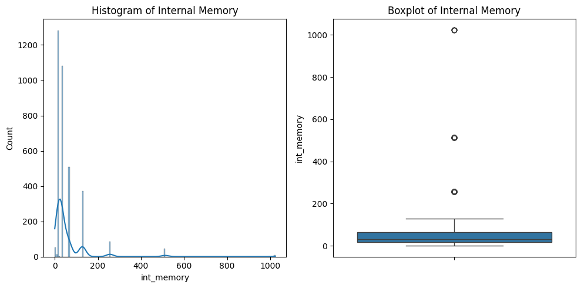

```python
# Plotting histogram and boxplot for int_memory
plt.figure(figsize=(10, 5))

plt.subplot(1, 2, 1)
sns.histplot(df['int_memory'], kde=True)
plt.title('Histogram of Internal Memory')

plt.subplot(1, 2, 2)
sns.boxplot(y=df['int_memory'])
plt.title('Boxplot of Internal Memory')

plt.tight_layout()
plt.show()
```

ram

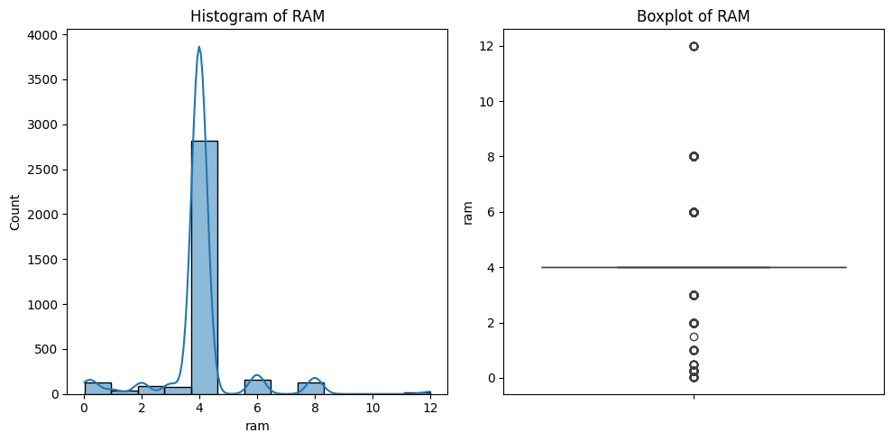

```python
# Plotting histogram and boxplot for ram
plt.figure(figsize=(10, 5))

plt.subplot(1, 2, 1)
sns.histplot(df['ram'], kde=True)
plt.title('Histogram of RAM')

plt.subplot(1, 2, 2)
sns.boxplot(y=df['ram'])
plt.title('Boxplot of RAM')

plt.tight_layout()
plt.show()
```

weight

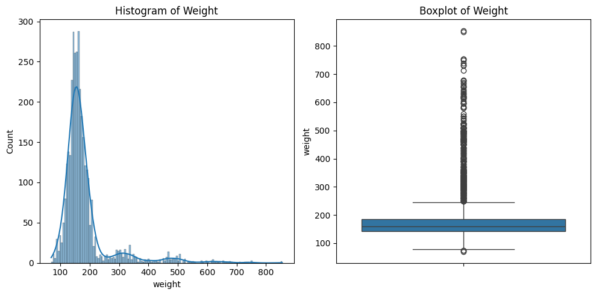

```python
# Plotting histogram and boxplot for weight
plt.figure(figsize=(10, 5))

plt.subplot(1, 2, 1)
sns.histplot(df['weight'], kde=True)
plt.title('Histogram of Weight')

plt.subplot(1, 2, 2)
sns.boxplot(y=df['weight'])
plt.title('Boxplot of Weight')

plt.tight_layout()
plt.show()
```

battery

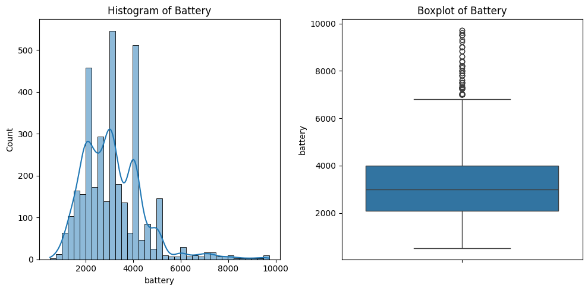

```python
# Plotting histogram and boxplot for battery
plt.figure(figsize=(10, 5))

plt.subplot(1, 2, 1)
sns.histplot(df['battery'], kde=True)
plt.title('Histogram of Battery')

plt.subplot(1, 2, 2)
sns.boxplot(y=df['battery'])
plt.title('Boxplot of Battery')

plt.tight_layout()
plt.show()
```

days_used

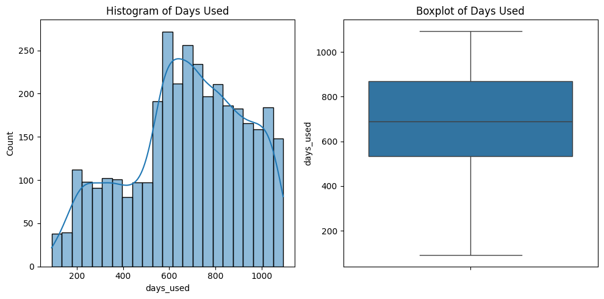

```python
# Plotting histogram and boxplot for days_used
plt.figure(figsize=(10, 5))

plt.subplot(1, 2, 1)
sns.histplot(df['days_used'], kde=True)
plt.title('Histogram of Days Used')

plt.subplot(1, 2, 2)
sns.boxplot(y=df['days_used'])
plt.title('Boxplot of Days Used')

plt.tight_layout()
plt.show()
```

brand_name

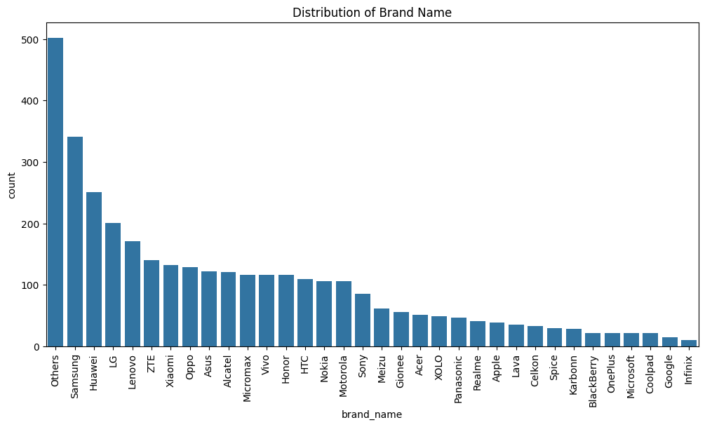

```python
# Plotting countplot for brand_name
plt.figure(figsize=(12, 6))
sns.countplot(x='brand_name', data=df, order=df['brand_name'].value_counts().index)
plt.title('Distribution of Brand Name')
plt.xticks(rotation=90)
plt.show()
```

os

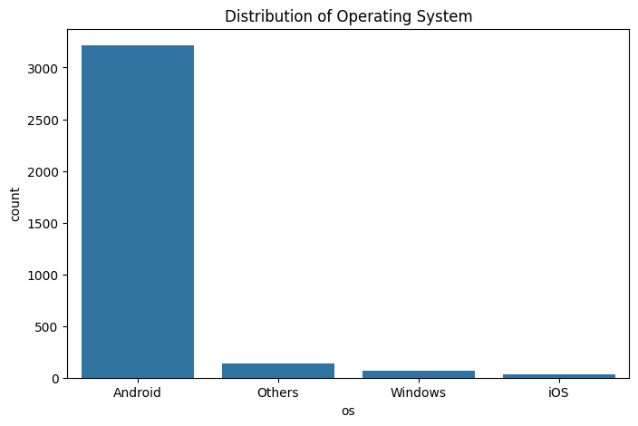

```python
# Plotting countplot for os
plt.figure(figsize=(8, 5))
sns.countplot(x='os', data=df, order=df['os'].value_counts().index)
plt.title('Distribution of Operating System')
plt.show()
```

4g

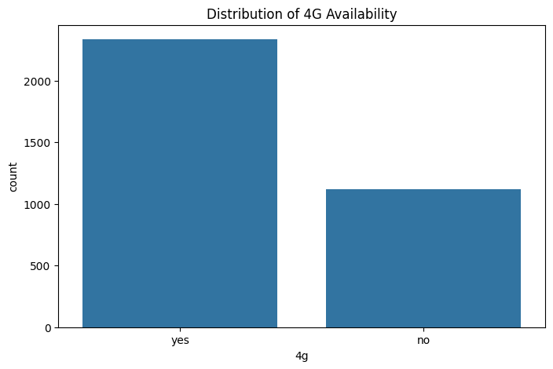

```python
# Plotting countplot for 4g
plt.figure(figsize=(8, 5))
sns.countplot(x='4g', data=df, order=df['4g'].value_counts().index)
plt.title('Distribution of 4G Availability')
plt.show()
```

5g

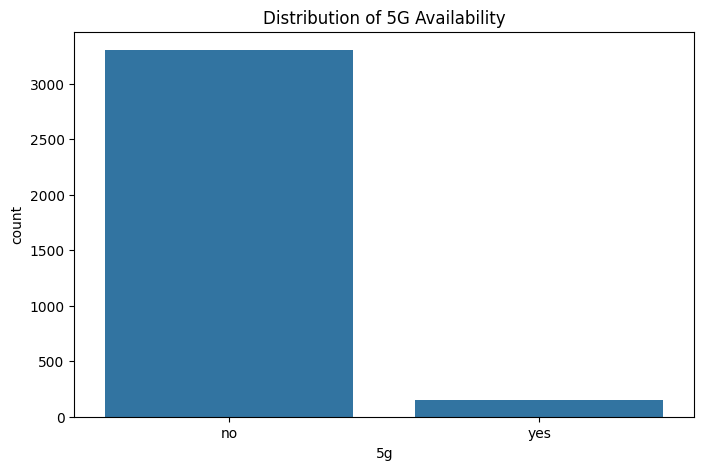

```python
# Plotting countplot for 5g
plt.figure(figsize=(8, 5))
sns.countplot(x='5g', data=df, order=df['5g'].value_counts().index)
plt.title('Distribution of 5G Availability')
plt.show()
```

release_year

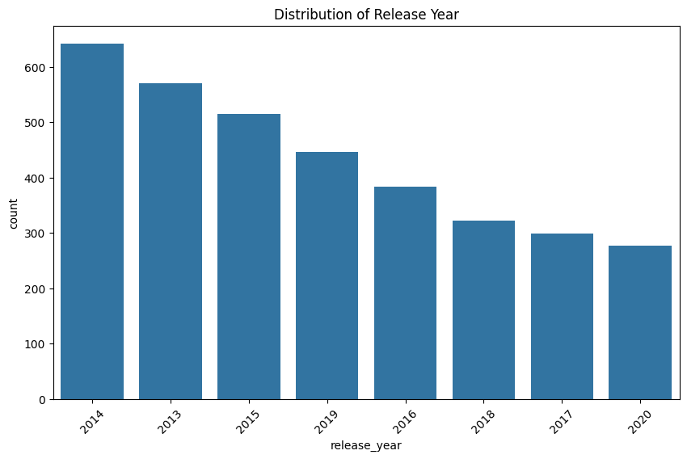

```python
# Plotting countplot for release_year
plt.figure(figsize=(10, 6))
sns.countplot(x='release_year', data=df, order=df['release_year'].value_counts().index)
plt.title('Distribution of Release Year')
plt.xticks(rotation=45)
plt.show()
```

### Bivariate Analysis

The percentage of the used device market dominated by Android devices

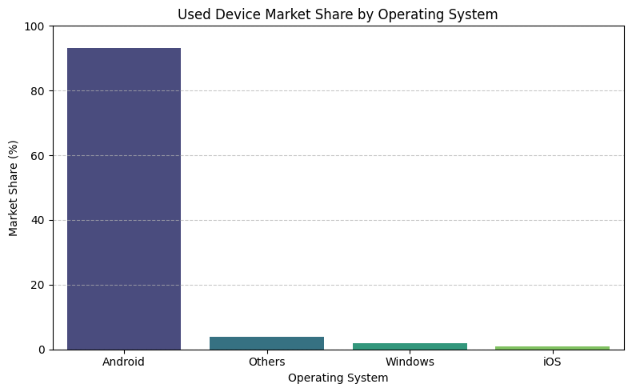

```
Percentage of used devices dominated by Android: 93.05%
```

```python
# Calculate the market share of each operating system
os_counts = df['os'].value_counts()
os_market_share = (os_counts / os_counts.sum()) * 100

# Create a DataFrame for plotting
plot_data = pd.DataFrame({'Operating System': os_market_share.index, 'Used Market Share (%)': os_market_share.values})

# Sort the data by market share for better visualization
plot_data = plot_data.sort_values(by='Used Market Share (%)', ascending=False)

plt.figure(figsize=(8, 5))
sns.barplot(x='Operating System', y='Used Market Share (%)', data=plot_data, palette='viridis')
plt.title('Used Device Market Share by Operating System')
plt.xlabel('Operating System')
plt.ylabel('Market Share (%)')
plt.ylim(0, 100)
plt.grid(axis='y', linestyle='--', alpha=0.7)
plt.tight_layout()
plt.show()

# Print the percentage of Android devices
android_percentage = os_market_share.get('Android', 0)
print(f"Percentage of used devices dominated by Android: {android_percentage:.2f}%")
```

**The amount of RAM is important for the smooth functioning of a device. Let's see how the amount of RAM varies across brands.**

```
            count      mean  median       std   min   max
brand_name
OnePlus        22  6.363636     6.0  2.592029  4.00  12.0
Acer           51  3.901961     4.0  0.500196  1.00   4.0
Alcatel       121  3.407025     4.0  1.263730  0.25   4.0
Apple          39  4.000000     4.0  0.606977  2.00   6.0
BlackBerry     22  3.829545     4.0  0.799503  0.25   4.0
Asus          122  4.049180     4.0  0.600997  2.00   8.0
Google         15  4.533333     4.0  0.915475  4.00   6.0
Gionee         56  3.933036     4.0  0.501115  0.25   4.0
HTC           110  4.000000     4.0  0.331801  3.00   6.0
Coolpad        22  3.954545     4.0  0.213201  3.00   4.0
Lenovo        171  3.885965     4.0  0.774222  0.25   6.0
Huawei        251  4.655378     4.0  1.595387  0.25  12.0
Karbonn        29  3.353448     4.0  1.441597  0.25   4.0
LG            201  3.936567     4.0  1.076461  0.25   8.0
Meizu          62  4.451613     4.0  1.223773  2.00   8.0
Lava           36  3.277778     4.0  1.413933  0.25   4.0
Micromax      117  3.679487     4.0  1.052934  0.25   4.0
Honor         116  4.603448     4.0  1.625232  2.00   8.0
Realme         41  4.195122     4.0  1.327018  2.00   6.0
Samsung       341  4.199413     4.0  1.377140  0.25  12.0
```

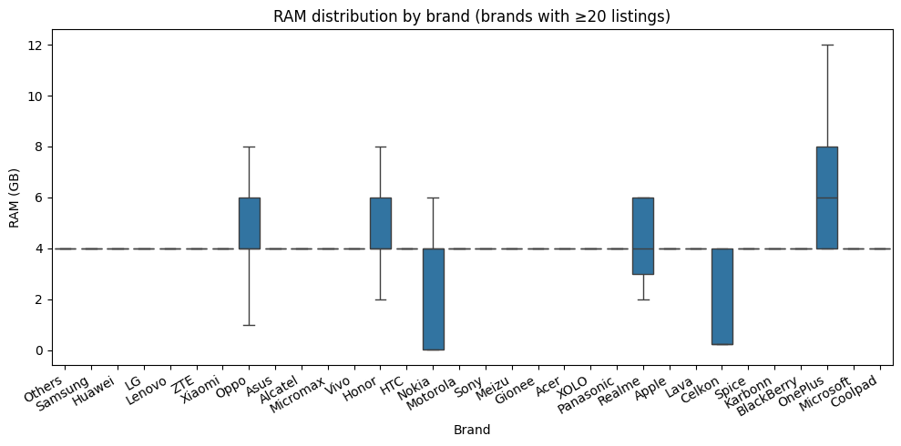

```python
# Summary stats
ram_by_brand = (df.groupby('brand_name', dropna=False)['ram']
                  .agg(['count','mean','median','std','min','max'])
                  .sort_values('median', ascending=False))
print(ram_by_brand.head(20))

# Visualization (filter to brands with enough samples)
brand_counts = df['brand_name'].value_counts()
big_brands = brand_counts[brand_counts >= 20].index  # adjust threshold as needed

plt.figure(figsize=(10,5))
sns.boxplot(data=df[df['brand_name'].isin(big_brands)],
            x='brand_name', y='ram', order=big_brands, showfliers=False)
plt.title('RAM distribution by brand (brands with ≥20 listings)')
plt.xlabel('Brand')
plt.ylabel('RAM (GB)')
plt.xticks(rotation=30, ha='right')
plt.tight_layout()
plt.show()
```

A large battery often increases a device's weight, making it feel uncomfortable in the hands.

Let`s see How does the weight vary for phones and tablets offering large batteries (more than 4500 mAh)?

```
             count    mean  median     std    min    max
device_type
Phone            1  270.00  270.00     NaN  270.0  270.0
Tablet         340  332.46  300.25  155.69  118.0  855.0
```

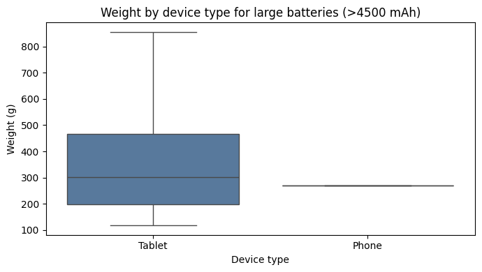

```python
# Create 'device_type' column based on screen size (assuming 7 inches as a threshold)
# This code was moved from a later cell to fix the KeyError.
df['device_type'] = np.where(df['screen_size'] >= 7, 'Tablet', 'Phone')

large_batt = df[df['battery'] > 4500].copy() # Added .copy() to avoid SettingWithCopyWarning

print(large_batt.groupby('device_type')['weight']
      .agg(['count','mean','median','std','min','max'])
      .round(2))

plt.figure(figsize=(7,4))
sns.boxplot(data=large_batt, x='device_type', y='weight', palette=['#4C78A8','#F58518'], showfliers=False)
plt.title('Weight by device type for large batteries (>4500 mAh)')
plt.xlabel('Device type')
plt.ylabel('Weight (g)')
plt.tight_layout()
plt.show()
```

Creating a 'device_type' column based on screen size to differentiate between phones and tablets.

```python
# Create 'device_type' column based on screen size (assuming 7 inches as a threshold)
df['device_type'] = np.where(df['screen_size'] >= 7, 'Tablet', 'Phone')

# Display the value counts for the new column
print(df['device_type'].value_counts())
```

```
device_type
Tablet    3361
Phone       93
Name: count, dtype: int64
```

Let`s see the distribution of devices offering greater than 8MP selfie cameras across brands

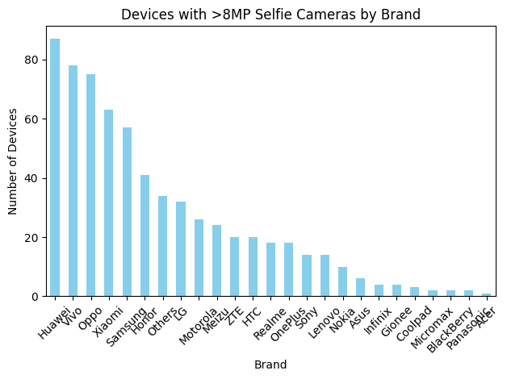

```python
import matplotlib.pyplot as plt

# Filter for devices with selfie camera MP greater than 8
high_selfie_mp_df = df[df['selfie_camera_mp'] > 8]

# Count the occurrences of each brand in the filtered data
brand_counts = high_selfie_mp_df['brand_name'].value_counts()

brand_counts.plot(kind='bar', color='skyblue')
plt.title('Devices with >8MP Selfie Cameras by Brand')
plt.xlabel('Brand')
plt.ylabel('Number of Devices')
plt.xticks(rotation=45)
plt.tight_layout()
plt.show()
```

### Multivariate Analysis

Count of phones and tablets with screen size > 6 inches, by brand

```
   brand_name device_type  count
9      Huawei      Tablet    149
24    Samsung      Tablet    119
21     Others      Tablet     99
27       Vivo      Tablet     80
8       Honor      Tablet     72
20       Oppo      Tablet     70
13     Lenovo      Tablet     69
29     Xiaomi      Tablet     69
12         LG      Tablet     59
17   Motorola      Tablet     42
3        Asus      Tablet     41
23     Realme      Tablet     40
1     Alcatel      Tablet     26
2       Apple      Tablet     24
0        Acer      Tablet     19
14      Meizu      Tablet     17
30        ZTE      Tablet     17
19    OnePlus      Tablet     16
18      Nokia      Tablet     15
25       Sony      Tablet     12
10    Infinix      Tablet     10
7         HTC      Tablet      7
15   Micromax      Tablet      7
6      Google      Tablet      4
4     Coolpad      Tablet      3
5      Gionee      Tablet      3
28       XOLO      Tablet      3
11    Karbonn      Tablet      2
22  Panasonic      Tablet      2
26      Spice      Tablet      2
device_type  Tablet
brand_name
Acer             19
Alcatel          26
Apple            24
Asus             41
Coolpad           3
Gionee            3
Google            4
HTC               7
Honor            72
Huawei          149
Infinix          10
Karbonn           2
LG               59
Lenovo           69
Meizu            17
Micromax          7
Microsoft         1
Motorola         42
Nokia            15
OnePlus          16
```

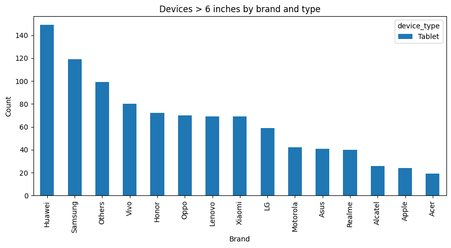

```python
# Define the conversion factor and the threshold for 6 inches in centimeters
inches_to_cm = 2.54
six_in_cm = 6 * inches_to_cm

big_screen = df[df['screen_size'] > six_in_cm]

counts = (big_screen
          .groupby(['brand_name','device_type'])
          .size()
          .reset_index(name='count')
          .sort_values(['device_type','count'], ascending=[True, False]))
print(counts.head(30))

# Pivot for readability
pivot_counts = counts.pivot(index='brand_name', columns='device_type', values='count').fillna(0).astype(int)
print(pivot_counts.head(20))

# Optional: stacked bar
top_brands = big_screen['brand_name'].value_counts().head(15).index
plot_df = counts[counts['brand_name'].isin(top_brands)]
plot_df = plot_df.pivot(index='brand_name', columns='device_type', values='count').fillna(0)

plot_df.loc[top_brands].plot(kind='bar', stacked=True, figsize=(9,5), colormap='tab20')
plt.title('Devices > 6 inches by brand and type')
plt.xlabel('Brand')
plt.ylabel('Count')
plt.tight_layout()
plt.show()
```

```python
# Define the conversion factor and the threshold for 6 inches in centimeters
inches_to_cm = 2.54
six_in_cm = 6 * inches_to_cm
```

attributes that are highly correlated with the normalized price of a used device

```
Correlation with normalized_used_price:
normalized_new_price    0.834
screen_size             0.615
battery                 0.614
selfie_camera_mp        0.608
main_camera_mp          0.587
ram                     0.520
release_year            0.510
weight                  0.382
days_used              -0.358
int_memory              0.191
Name: normalized_used_price, dtype: float64
```

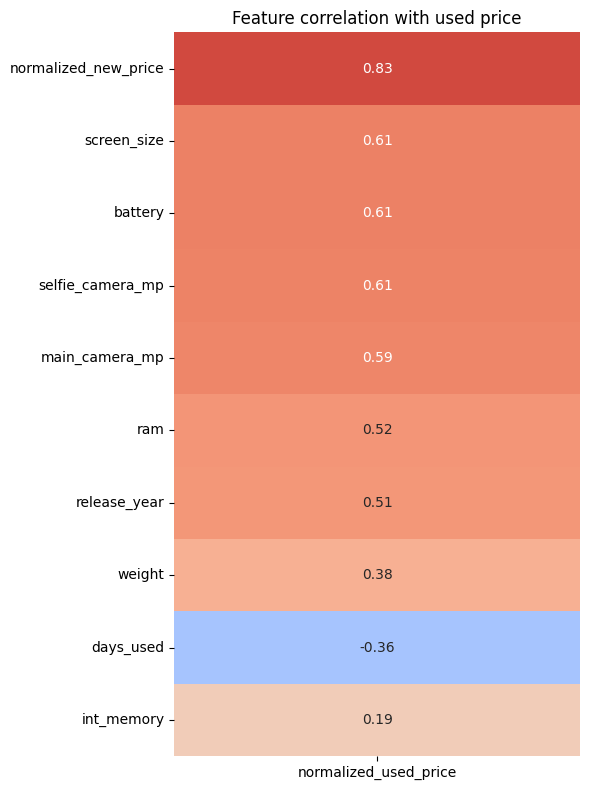

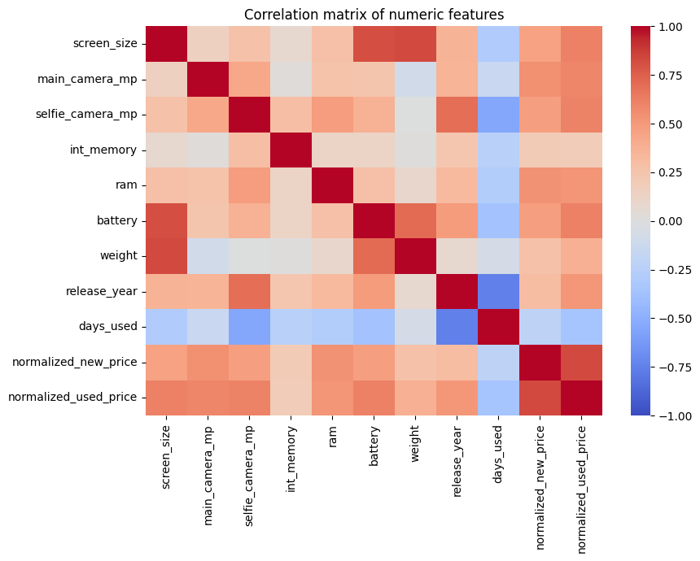

```python
# Prepare numeric features (including binary 4g/5g)
feat_cols = ['screen_size','main_camera_mp','selfie_camera_mp','int_memory','ram','battery','weight',
             'release_year','days_used','normalized_new_price','4g','5g']
corr = df[feat_cols + ['normalized_used_price']].corr(numeric_only=True)

target_corr = corr['normalized_used_price'].drop('normalized_used_price').sort_values(key=np.abs, ascending=False)
print('Correlation with normalized_used_price:')
print(target_corr.round(3))

plt.figure(figsize=(6,8))
sns.heatmap(target_corr.to_frame(), annot=True, fmt='.2f', cmap='coolwarm', vmin=-1, vmax=1, cbar=False)
plt.title('Feature correlation with used price')
plt.tight_layout()
plt.show()

# Optional: multicollinearity view
plt.figure(figsize=(9,7))
sns.heatmap(corr, cmap='coolwarm', vmin=-1, vmax=1, annot=False)
plt.title('Correlation matrix of numeric features')
plt.tight_layout()
plt.show()
```

## Data Preprocessing

- Missing value treatment
- Feature engineering (if needed)
- Outlier detection and treatment (if needed)
- Preparing data for modeling
- Any other preprocessing steps (if needed)

### Missing value treatment

```python
df1 = df.copy()
```

```python
# Check for missing values
df1.isnull().sum()
```

|  | 0 |
| --- | --- |
| brand_name | 0 |
| os | 0 |
| screen_size | 0 |
| 4g | 0 |
| 5g | 0 |
| main_camera_mp | 179 |
| selfie_camera_mp | 2 |
| int_memory | 4 |
| ram | 4 |
| battery | 6 |
| weight | 7 |
| release_year | 0 |
| days_used | 0 |
| normalized_used_price | 0 |
| normalized_new_price | 0 |
| device_type | 0 |

**dtype:** int64

```python
cols_impute = [
    "main_camera_mp",
    "selfie_camera_mp",
    "int_memory",
    "ram",
    "battery",
    "weight",
]

for col in cols_impute:
    df1[col] = df1[col].fillna(
        value=df1[col].median()
    )
```

```python
# checking for missing values
df1.isnull().sum()
```

|  | 0 |
| --- | --- |
| brand_name | 0 |
| os | 0 |
| screen_size | 0 |
| 4g | 0 |
| 5g | 0 |
| main_camera_mp | 0 |
| selfie_camera_mp | 0 |
| int_memory | 0 |
| ram | 0 |
| battery | 0 |
| weight | 0 |
| release_year | 0 |
| days_used | 0 |
| normalized_used_price | 0 |
| normalized_new_price | 0 |
| device_type | 0 |

**dtype:** int64

```python
columns_to_impute = [
    "main_camera_mp",
    "selfie_camera_mp",
    "int_memory",
    "ram",
    "battery",
    "weight",
]

for col in columns_to_impute:
    df1[col] = df1[col].fillna(
        value=df1.groupby(['brand_name'])[col].transform("median")
    )
```

```python
df1["main_camera_mp"] = df1["main_camera_mp"].fillna(df1["main_camera_mp"].median())
```

```python
# checking for missing values,
df1.isnull().sum()
```

|  | 0 |
| --- | --- |
| brand_name | 0 |
| os | 0 |
| screen_size | 0 |
| 4g | 0 |
| 5g | 0 |
| main_camera_mp | 0 |
| selfie_camera_mp | 0 |
| int_memory | 0 |
| ram | 0 |
| battery | 0 |
| weight | 0 |
| release_year | 0 |
| days_used | 0 |
| normalized_used_price | 0 |
| normalized_new_price | 0 |
| device_type | 0 |

**dtype:** int64

### Feature Engineering

- Let's create a new column `years_since_release` from the `release_year` column.
- the year of data collection, 2021, as the baseline.

```python
df1["years_since_release"] = 2021 - df1["release_year"]
df1.drop("release_year", axis=1, inplace=True)
df1["years_since_release"].describe()
```

|  | years_since_release |
| --- | --- |
| count | 3454.000000 |
| mean | 5.034742 |
| std | 2.298455 |
| min | 1.000000 |
| 25% | 3.000000 |
| 50% | 5.500000 |
| 75% | 7.000000 |
| max | 8.000000 |

**dtype:** float64

### Outlier Check

. Let's check for outliers in the data.

```python
# List of numerical columns to check for outliers
numerical_cols = df.select_dtypes(include=np.number).columns.tolist()

# Exclude the target variable and year_since_release from outlier check as they represent time or target
# and outliers might be meaningful data points
cols_to_check_outliers = [col for col in numerical_cols if col not in ['normalized_used_price', 'release_year', 'years_since_release']]


for col in cols_to_check_outliers:
    Q1 = df[col].quantile(0.25)
    Q3 = df[col].quantile(0.75)
    IQR = Q3 - Q1

    lower_bound = Q1 - 1.5 * IQR
    upper_bound = Q3 + 1.5 * IQR

    outliers = df[(df[col] < lower_bound) | (df[col] > upper_bound)]

    print(f"Outliers for column '{col}':")
    print(outliers.shape[0]) # Print the number of outliers
    # Optionally, display the outlier rows for inspection:
    # display(outliers)
```

```
Outliers for column 'screen_size':
450
Outliers for column 'main_camera_mp':
5
Outliers for column 'selfie_camera_mp':
221
Outliers for column 'int_memory':
138
Outliers for column 'ram':
635
Outliers for column 'battery':
77
Outliers for column 'weight':
368
Outliers for column 'days_used':
0
Outliers for column 'normalized_new_price':
66
```

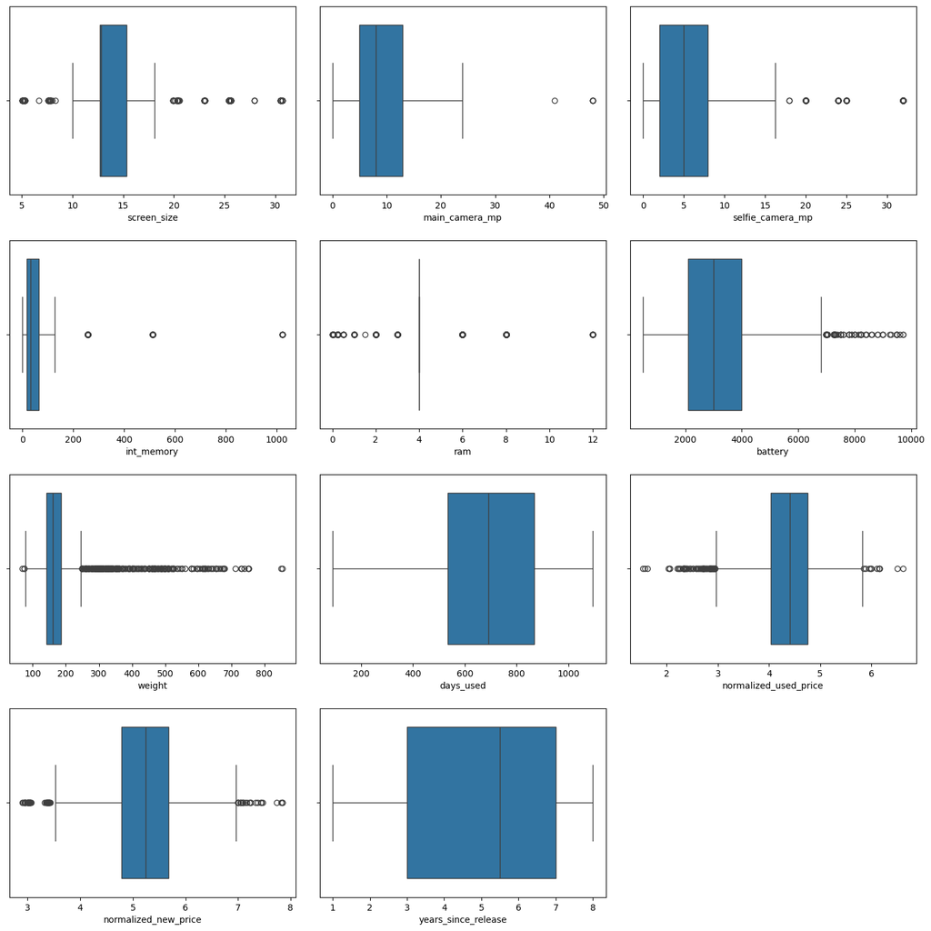

```python
# outlier detection using boxplot
num_cols = df1.select_dtypes(include=np.number).columns.tolist()

plt.figure(figsize=(15, 15))

for i, variable in enumerate(num_cols):
    plt.subplot(4, 3, i + 1)
    sns.boxplot(data=df1, x=variable)
    plt.tight_layout(pad=2)

plt.show()
```

### Data Preparation for modeling

- We want to predict the normalized price of used devices
- Before we proceed to build a model, we'll have to encode categorical features
- We'll split the data into train and test to be able to evaluate the model that we build on the train data
- We will build a Linear Regression model using the train data and then check it's performance

Let`s define the dependent and independent variables

```python
X = df1.drop(['normalized_used_price'], axis=1)
Y = df1['normalized_used_price']
print(X.head())
print()
print(Y.head())
```

```
  brand_name       os  screen_size   4g   5g  main_camera_mp  \
0      Honor  Android        14.50  yes   no            13.0
1      Honor  Android        17.30  yes  yes            13.0
2      Honor  Android        16.69  yes  yes            13.0
3      Honor  Android        25.50  yes  yes            13.0
4      Honor  Android        15.32  yes   no            13.0

   selfie_camera_mp  int_memory  ram  battery  weight  days_used  \
0               5.0        64.0  3.0   3020.0   146.0        127
1              16.0       128.0  8.0   4300.0   213.0        325
2               8.0       128.0  8.0   4200.0   213.0        162
3               8.0        64.0  6.0   7250.0   480.0        345
4               8.0        64.0  3.0   5000.0   185.0        293

   normalized_new_price device_type  years_since_release
0              4.715100      Tablet                    1
1              5.519018      Tablet                    1
2              5.884631      Tablet                    1
3              5.630961      Tablet                    1
4              4.947837      Tablet                    1

0    4.307572
1    5.162097
2    5.111084
3    5.135387
4    4.389995
Name: normalized_used_price, dtype: float64
```

```python
# let's add the intercept to data
X = sm.add_constant(X)
```

```python
# Let`s creat dummy variables
X = pd.get_dummies(
    X,
    columns=X.select_dtypes(include=["object", "category"]).columns.tolist(),
    drop_first=True,
)
X.head()
```

|  | const | screen_size | main_camera_mp | selfie_camera_mp | int_memory | ram | battery | weight | days_used | normalized_new_price | ... | brand_name_Vivo | brand_name_XOLO | brand_name_Xiaomi | brand_name_ZTE | os_Others | os_Windows | os_iOS | 4g_yes | 5g_yes | device_type_Tablet |
| --- | --- | --- | --- | --- | --- | --- | --- | --- | --- | --- | --- | --- | --- | --- | --- | --- | --- | --- | --- | --- | --- |
| 0 | 1.0 | 14.50 | 13.0 | 5.0 | 64.0 | 3.0 | 3020.0 | 146.0 | 127 | 4.715100 | ... | False | False | False | False | False | False | False | True | False | True |
| 1 | 1.0 | 17.30 | 13.0 | 16.0 | 128.0 | 8.0 | 4300.0 | 213.0 | 325 | 5.519018 | ... | False | False | False | False | False | False | False | True | True | True |
| 2 | 1.0 | 16.69 | 13.0 | 8.0 | 128.0 | 8.0 | 4200.0 | 213.0 | 162 | 5.884631 | ... | False | False | False | False | False | False | False | True | True | True |
| 3 | 1.0 | 25.50 | 13.0 | 8.0 | 64.0 | 6.0 | 7250.0 | 480.0 | 345 | 5.630961 | ... | False | False | False | False | False | False | False | True | True | True |
| 4 | 1.0 | 15.32 | 13.0 | 8.0 | 64.0 | 3.0 | 5000.0 | 185.0 | 293 | 4.947837 | ... | False | False | False | False | False | False | False | True | False | True |

5 rows × 50 columns

```python
# splitting the data in 70:30 ratio for train to test data
X_train, X_test, y_train, y_test = train_test_split(
    X, Y, test_size=0.3, random_state=42
)
```

```python
print("Number of rows in train data =", X_train.shape[0])
print("Number of rows in test data =", X_test.shape[0])
```

```
Number of rows in train data = 2417
Number of rows in test data = 1037
```

## EDA

```python
print(df.shape)
```

[output not shown]

```python
print(df.info())
```

[output not shown]

```python
df.describe()
```

|  | screen_size | main_camera_mp | selfie_camera_mp | int_memory | ram | battery | weight | release_year | days_used | normalized_used_price | normalized_new_price |
| --- | --- | --- | --- | --- | --- | --- | --- | --- | --- | --- | --- |
| count | 3454.000000 | 3275.000000 | 3452.000000 | 3450.000000 | 3450.000000 | 3448.000000 | 3447.000000 | 3454.000000 | 3454.000000 | 3454.000000 | 3454.000000 |
| mean | 13.713115 | 9.460208 | 6.554229 | 54.573099 | 4.036122 | 3133.402697 | 182.751871 | 2015.965258 | 674.869716 | 4.364712 | 5.233107 |
| std | 3.805280 | 4.815461 | 6.970372 | 84.972371 | 1.365105 | 1299.682844 | 88.413228 | 2.298455 | 248.580166 | 0.588914 | 0.683637 |
| min | 5.080000 | 0.080000 | 0.000000 | 0.010000 | 0.020000 | 500.000000 | 69.000000 | 2013.000000 | 91.000000 | 1.536867 | 2.901422 |
| 25% | 12.700000 | 5.000000 | 2.000000 | 16.000000 | 4.000000 | 2100.000000 | 142.000000 | 2014.000000 | 533.500000 | 4.033931 | 4.790342 |
| 50% | 12.830000 | 8.000000 | 5.000000 | 32.000000 | 4.000000 | 3000.000000 | 160.000000 | 2015.500000 | 690.500000 | 4.405133 | 5.245892 |
| 75% | 15.340000 | 13.000000 | 8.000000 | 64.000000 | 4.000000 | 4000.000000 | 185.000000 | 2018.000000 | 868.750000 | 4.755700 | 5.673718 |
| max | 30.710000 | 48.000000 | 32.000000 | 1024.000000 | 12.000000 | 9720.000000 | 855.000000 | 2020.000000 | 1094.000000 | 6.619433 | 7.847841 |

```python
df.head()
```

[output not shown]

## Model Building - Linear Regression

```python
# Convert relevant columns to numeric, coercing errors
for col in ['screen_size', 'main_camera_mp', 'selfie_camera_mp', 'int_memory', 'ram', 'battery', 'weight', 'days_used', 'normalized_new_price', 'years_since_release']:
    df1[col] = pd.to_numeric(df1[col], errors='coerce')

# Check data types after conversion
print(df1.dtypes)
```

```
brand_name                object
os                        object
screen_size              float64
4g                        object
5g                        object
main_camera_mp           float64
selfie_camera_mp         float64
int_memory               float64
ram                      float64
battery                  float64
weight                   float64
days_used                  int64
normalized_used_price    float64
normalized_new_price     float64
device_type               object
years_since_release        int64
dtype: object
```

```python
# Handle missing values after numeric conversion
# Impute remaining missing values with the median of the respective column
for col in ['main_camera_mp', 'selfie_camera_mp', 'int_memory', 'ram', 'battery', 'weight']:
    df1[col] = df1[col].fillna(df1[col].median())

# Check for any remaining NaNs after imputation
print("\nMissing values after imputation:")
print(df1.isnull().sum())
```

```
Missing values after imputation:
brand_name               0
os                       0
screen_size              0
4g                       0
5g                       0
main_camera_mp           0
selfie_camera_mp         0
int_memory               0
ram                      0
battery                  0
weight                   0
days_used                0
normalized_used_price    0
normalized_new_price     0
device_type              0
years_since_release      0
dtype: int64
```

```python
# Create dummy variables for categorical features
categorical_cols = df1.select_dtypes(include=['object', 'category']).columns
df1 = pd.get_dummies(df1, columns=categorical_cols, drop_first=True)

# Display the first few rows and info of the modified DataFrame
display(df1.head())
df1.info()
```

|  | screen_size | main_camera_mp | selfie_camera_mp | int_memory | ram | battery | weight | days_used | normalized_used_price | normalized_new_price | ... | brand_name_Vivo | brand_name_XOLO | brand_name_Xiaomi | brand_name_ZTE | os_Others | os_Windows | os_iOS | 4g_yes | 5g_yes | device_type_Tablet |
| --- | --- | --- | --- | --- | --- | --- | --- | --- | --- | --- | --- | --- | --- | --- | --- | --- | --- | --- | --- | --- | --- |
| 0 | 14.50 | 13.0 | 5.0 | 64.0 | 3.0 | 3020.0 | 146.0 | 127 | 4.307572 | 4.715100 | ... | False | False | False | False | False | False | False | True | False | True |
| 1 | 17.30 | 13.0 | 16.0 | 128.0 | 8.0 | 4300.0 | 213.0 | 325 | 5.162097 | 5.519018 | ... | False | False | False | False | False | False | False | True | True | True |
| 2 | 16.69 | 13.0 | 8.0 | 128.0 | 8.0 | 4200.0 | 213.0 | 162 | 5.111084 | 5.884631 | ... | False | False | False | False | False | False | False | True | True | True |
| 3 | 25.50 | 13.0 | 8.0 | 64.0 | 6.0 | 7250.0 | 480.0 | 345 | 5.135387 | 5.630961 | ... | False | False | False | False | False | False | False | True | True | True |
| 4 | 15.32 | 13.0 | 8.0 | 64.0 | 3.0 | 5000.0 | 185.0 | 293 | 4.389995 | 4.947837 | ... | False | False | False | False | False | False | False | True | False | True |

5 rows × 50 columns

```
<class 'pandas.core.frame.DataFrame'>
RangeIndex: 3454 entries, 0 to 3453
Data columns (total 50 columns):
 #   Column                 Non-Null Count  Dtype
---  ------                 --------------  -----
 0   screen_size            3454 non-null   float64
 1   main_camera_mp         3454 non-null   float64
 2   selfie_camera_mp       3454 non-null   float64
 3   int_memory             3454 non-null   float64
 4   ram                    3454 non-null   float64
 5   battery                3454 non-null   float64
 6   weight                 3454 non-null   float64
 7   days_used              3454 non-null   int64
 8   normalized_used_price  3454 non-null   float64
 9   normalized_new_price   3454 non-null   float64
```

[output cut: 42 more lines]

```python
# Define the dependent variable (target) and independent variables (features) after preprocessing
X = df1.drop(['normalized_used_price'], axis=1)
Y = df1['normalized_used_price']

# splitting the data in 70:30 ratio for train to test data
X_train, X_test, y_train, y_test = train_test_split(
    X, Y, test_size=0.3, random_state=42
)

# Add a constant to the training data for the OLS model
X_train = sm.add_constant(X_train)

# Display the shapes of the train and test sets
print("Shape of X_train:", X_train.shape)
print("Shape of X_test:", X_test.shape)
print("Shape of y_train:", y_train.shape)
print("Shape of y_test:", y_test.shape)
```

```
Shape of X_train: (2417, 50)
Shape of X_test: (1037, 49)
Shape of y_train: (2417,)
Shape of y_test: (1037,)
```

```python
X_train = X_train.astype(float)
y_train = y_train.astype(float)
# Fit the OLS model
olsmodel1 = sm.OLS(y_train, X_train)
results = olsmodel1.fit()
print(results.summary())
```

```
                              OLS Regression Results
=================================================================================
Dep. Variable:     normalized_used_price   R-squared:                       0.849
Model:                               OLS   Adj. R-squared:                  0.845
Method:                    Least Squares   F-statistic:                     270.6
Date:                   Fri, 19 Sep 2025   Prob (F-statistic):               0.00
Time:                           14:36:10   Log-Likelihood:                 122.27
No. Observations:                   2417   AIC:                            -144.5
Df Residuals:                       2367   BIC:                             145.0
Df Model:                             49
Covariance Type:               nonrobust
=========================================================================================
                            coef    std err          t      P>|t|      [0.025      0.975]
-----------------------------------------------------------------------------------------
const                     1.4525      0.086     16.981      0.000       1.285       1.620
screen_size               0.0296      0.004      8.128      0.000       0.022       0.037
main_camera_mp            0.0223      0.002     14.619      0.000       0.019       0.025
selfie_camera_mp          0.0118      0.001     10.007      0.000       0.009       0.014
int_memory                0.0002   6.78e-05      2.692      0.007    4.95e-05       0.000
ram                       0.0316      0.005      6.017      0.000       0.021       0.042
battery               -1.492e-05   7.37e-06     -2.024      0.043   -2.94e-05   -4.66e-07
weight                    0.0008      0.000      5.734      0.000       0.001       0.001
days_used              2.684e-05   3.08e-05      0.871      0.384   -3.36e-05    8.73e-05
normalized_new_price      0.4116      0.012     33.525      0.000       0.387       0.436
years_since_release      -0.0266      0.005     -5.828      0.000      -0.036      -0.018
brand_name_Alcatel       -0.0806      0.050     -1.620      0.105      -0.178       0.017
brand_name_Apple         -0.0361      0.151     -0.239      0.811      -0.333       0.261
brand_name_Asus           0.0108      0.049      0.219      0.826      -0.086       0.108
brand_name_BlackBerry     0.0386      0.073      0.526      0.599      -0.105       0.182
brand_name_Celkon        -0.2338      0.068     -3.431      0.001      -0.367      -0.100
brand_name_Coolpad       -0.0185      0.071     -0.261      0.794      -0.158       0.121
brand_name_Gionee        -0.0132      0.059     -0.225      0.822      -0.128       0.102
brand_name_Google        -0.1211      0.083     -1.463      0.144      -0.283       0.041
brand_name_HTC           -0.0394      0.050     -0.788      0.431      -0.138       0.059
brand_name_Honor         -0.0566      0.051     -1.114      0.266      -0.156       0.043
brand_name_Huawei        -0.0666      0.046     -1.442      0.149      -0.157       0.024
brand_name_Infinix        0.1233      0.114      1.085      0.278      -0.099       0.346
brand_name_Karbonn       -0.0569      0.068     -0.833      0.405      -0.191       0.077
brand_name_LG            -0.0647      0.047     -1.381      0.168      -0.157       0.027
brand_name_Lava          -0.0223      0.063     -0.353      0.724      -0.146       0.102
```

[output cut: 20 more lines]

```
os_iOS                   -0.0233      0.152     -0.153      0.878      -0.321       0.274
4g_yes                    0.0394      0.016      2.431      0.015       0.008       0.071
5g_yes                   -0.0605      0.033     -1.862      0.063      -0.124       0.003
device_type_Tablet       -0.0272      0.055     -0.490      0.624      -0.136       0.082
==============================================================================
Omnibus:                      235.709   Durbin-Watson:                   1.990
Prob(Omnibus):                  0.000   Jarque-Bera (JB):              632.420
Skew:                          -0.539   Prob(JB):                    4.70e-138
Kurtosis:                       5.262   Cond. No.                     1.85e+05
==============================================================================

Notes:
[1] Standard Errors assume that the covariance matrix of the errors is correctly specified.
[2] The condition number is large, 1.85e+05. This might indicate that there are
strong multicollinearity or other numerical problems.
```

## Model Performance Check

**Let's check the performance of the model using different metrics.**

```python
# function to compute adjusted R-squared
def adj_r2_score(predictors, targets, predictions):
    r2 = r2_score(targets, predictions)
    n = predictors.shape[0]
    k = predictors.shape[1]
    return 1 - ((1 - r2) * (n - 1) / (n - k - 1))


# function to compute MAPE
def mape_score(targets, predictions):
    return np.mean(np.abs(targets - predictions) / targets) * 100


# function to compute different metrics to check performance of a regression model
def model_performance_regression(model, predictors, target):
    """
    Function to compute different metrics to check regression model performance

    model: regressor
    predictors: independent variables
    target: dependent variable
    """
    # Add a constant to the predictors if it's not already present
    predictors = sm.add_constant(predictors, has_constant='add')


    # predicting using the independent variables
    pred = model.predict(predictors)

    r2 = r2_score(target, pred)  # to compute R-squared
    adjr2 = adj_r2_score(predictors, target, pred)  # to compute adjusted R-squared
    rmse = np.sqrt(mean_squared_error(target, pred))  # to compute RMSE
    mae = mean_absolute_error(target, pred)  # to compute MAE
    mape = mape_score(target, pred)  # to compute MAPE

    # creating a dataframe of metrics
    df_perf = pd.DataFrame(
        {
            "RMSE": rmse,
            "MAE": mae,
            "R-squared": r2,
            "Adj. R-squared": adjr2,
            "MAPE": mape,
        },
        index=[0],
    )

    return df_perf
```

```python
# checking model performance on train set (seen 70% data)
print("Training Performance\n")
olsmodel1_train_perf = model_performance_regression(results, X_train, y_train)
olsmodel1_train_perf
```

```
Training Performance
```

|  | RMSE | MAE | R-squared | Adj. R-squared | MAPE |
| --- | --- | --- | --- | --- | --- |
| 0 | 0.230035 | 0.178408 | 0.848526 | 0.845325 | 4.291405 |

```python
# checking model performance on test set (seen 30% data)
print("Test Performance\n")
# Evaluate on test
olsmodel1_test_perf = model_performance_regression(results, X_test, y_test)
olsmodel1_test_perf
```

```
Test Performance
```

|  | RMSE | MAE | R-squared | Adj. R-squared | MAPE |
| --- | --- | --- | --- | --- | --- |
| 0 | 0.238396 | 0.18842 | 0.833109 | 0.824645 | 4.510944 |

## Review data types and missing values

### Subtask:

Re-examine the data types and missing values after creating the `df1` copy and the `years_since_release` column.

**Reasoning**: Display the data types and check for missing values in the df1 DataFrame after creating the years_since_release column to re-examine the data.

```python
### Check Data Types
print(df1.dtypes)
```

```
screen_size              float64
main_camera_mp           float64
selfie_camera_mp         float64
int_memory               float64
ram                      float64
battery                  float64
weight                   float64
days_used                  int64
normalized_used_price    float64
normalized_new_price     float64
years_since_release        int64
brand_name_Alcatel          bool
brand_name_Apple            bool
brand_name_Asus             bool
brand_name_BlackBerry       bool
brand_name_Celkon           bool
brand_name_Coolpad          bool
brand_name_Gionee           bool
brand_name_Google           bool
brand_name_HTC              bool
brand_name_Honor            bool
brand_name_Huawei           bool
brand_name_Infinix          bool
brand_name_Karbonn          bool
brand_name_LG               bool
brand_name_Lava             bool
brand_name_Lenovo           bool
brand_name_Meizu            bool
brand_name_Micromax         bool
brand_name_Microsoft        bool
brand_name_Motorola         bool
brand_name_Nokia            bool
brand_name_OnePlus          bool
brand_name_Oppo             bool
brand_name_Others           bool
brand_name_Panasonic        bool
brand_name_Realme           bool
brand_name_Samsung          bool
brand_name_Sony             bool
brand_name_Spice            bool
brand_name_Vivo             bool
brand_name_XOLO             bool
brand_name_Xiaomi           bool
brand_name_ZTE              bool
os_Others                   bool
os_Windows                  bool
os_iOS                      bool
4g_yes                      bool
5g_yes                      bool
device_type_Tablet          bool
dtype: object
```

```python
df1.info()
```

```
<class 'pandas.core.frame.DataFrame'>
RangeIndex: 3454 entries, 0 to 3453
Data columns (total 50 columns):
 #   Column                 Non-Null Count  Dtype
---  ------                 --------------  -----
 0   screen_size            3454 non-null   float64
 1   main_camera_mp         3454 non-null   float64
 2   selfie_camera_mp       3454 non-null   float64
 3   int_memory             3454 non-null   float64
 4   ram                    3454 non-null   float64
 5   battery                3454 non-null   float64
 6   weight                 3454 non-null   float64
 7   days_used              3454 non-null   int64
 8   normalized_used_price  3454 non-null   float64
 9   normalized_new_price   3454 non-null   float64
```

[output cut: 42 more lines]

```python
### Check for Missing Values
print(df1.isnull().sum())
```

```
screen_size              0
main_camera_mp           0
selfie_camera_mp         0
int_memory               0
ram                      0
battery                  0
weight                   0
days_used                0
normalized_used_price    0
normalized_new_price     0
years_since_release      0
brand_name_Alcatel       0
brand_name_Apple         0
brand_name_Asus          0
brand_name_BlackBerry    0
brand_name_Celkon        0
brand_name_Coolpad       0
brand_name_Gionee        0
brand_name_Google        0
brand_name_HTC           0
brand_name_Honor         0
brand_name_Huawei        0
brand_name_Infinix       0
brand_name_Karbonn       0
brand_name_LG            0
brand_name_Lava          0
brand_name_Lenovo        0
brand_name_Meizu         0
brand_name_Micromax      0
brand_name_Microsoft     0
brand_name_Motorola      0
brand_name_Nokia         0
brand_name_OnePlus       0
brand_name_Oppo          0
brand_name_Others        0
brand_name_Panasonic     0
brand_name_Realme        0
brand_name_Samsung       0
brand_name_Sony          0
brand_name_Spice         0
brand_name_Vivo          0
brand_name_XOLO          0
brand_name_Xiaomi        0
brand_name_ZTE           0
os_Others                0
os_Windows               0
os_iOS                   0
4g_yes                   0
5g_yes                   0
device_type_Tablet       0
dtype: int64
```

## Checking Linear Regression Assumptions

- In order to make statistical inferences from a linear regression model, it is important to ensure that the assumptions of linear regression are satisfied.

# TEST FOR LINEARITY

```python
df_pred = pd.DataFrame()

df_pred["Actual Values"] = y_train.values.flatten()  # actual values
df_pred["Fitted Values"] = results.fittedvalues.values  # predicted values
df_pred["Residuals"] = results.resid.values  # residuals

df_pred.head()
```

|  | Actual Values | Fitted Values | Residuals |
| --- | --- | --- | --- |
| 0 | 4.261975 | 4.286224 | -0.024249 |
| 1 | 4.175156 | 3.875924 | 0.299232 |
| 2 | 4.117410 | 4.439098 | -0.321688 |
| 3 | 3.782597 | 3.818151 | -0.035553 |
| 4 | 3.981922 | 3.898643 | 0.083279 |

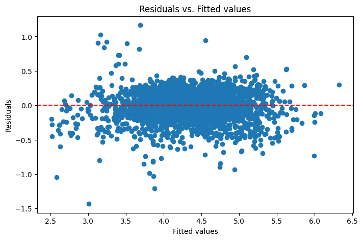

```python
# Plotting residuals vs fitted values to check linearity
plt.figure(figsize=(8, 5))
plt.scatter(df_pred["Fitted Values"], df_pred["Residuals"])
plt.axhline(y=0, color='r', linestyle='--')
plt.title('Residuals vs. Fitted values')
plt.xlabel('Fitted values')
plt.ylabel('Residuals')
plt.show()
```

```python
# columns in training set
print(X_train.columns)
```

```
Index(['const', 'screen_size', 'main_camera_mp', 'selfie_camera_mp',
       'int_memory', 'ram', 'battery', 'weight', 'days_used',
       'normalized_new_price', 'years_since_release', 'brand_name_Alcatel',
       'brand_name_Apple', 'brand_name_Asus', 'brand_name_BlackBerry',
       'brand_name_Celkon', 'brand_name_Coolpad', 'brand_name_Gionee',
       'brand_name_Google', 'brand_name_HTC', 'brand_name_Honor',
       'brand_name_Huawei', 'brand_name_Infinix', 'brand_name_Karbonn',
       'brand_name_LG', 'brand_name_Lava', 'brand_name_Lenovo',
       'brand_name_Meizu', 'brand_name_Micromax', 'brand_name_Microsoft',
       'brand_name_Motorola', 'brand_name_Nokia', 'brand_name_OnePlus',
       'brand_name_Oppo', 'brand_name_Others', 'brand_name_Panasonic',
       'brand_name_Realme', 'brand_name_Samsung', 'brand_name_Sony',
       'brand_name_Spice', 'brand_name_Vivo', 'brand_name_XOLO',
       'brand_name_Xiaomi', 'brand_name_ZTE', 'os_Others', 'os_Windows',
       'os_iOS', '4g_yes', '5g_yes', 'device_type_Tablet'],
      dtype='object')
```

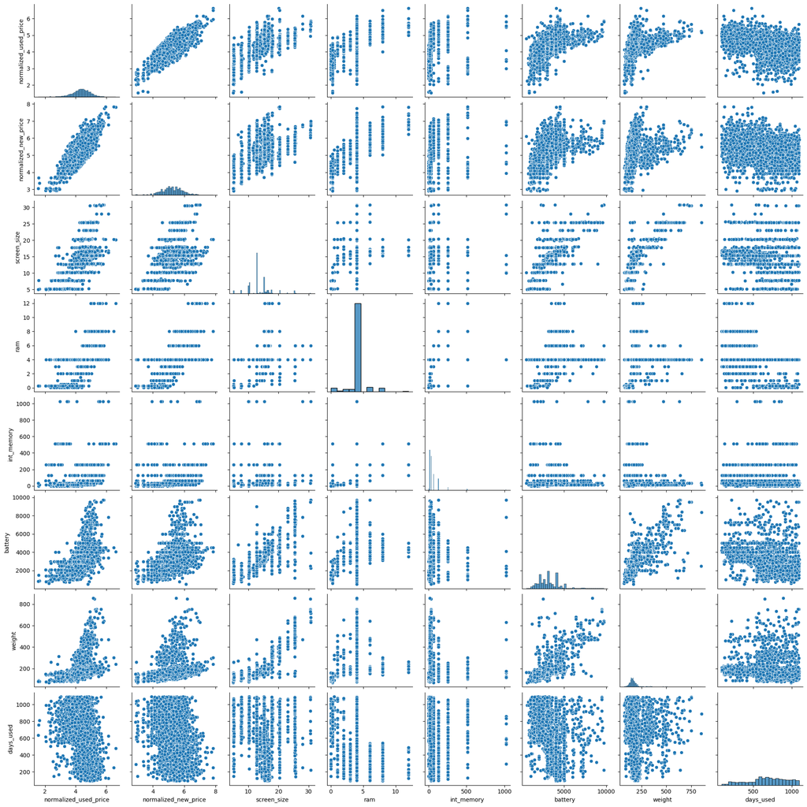

```python
# checking the distribution of some key variables in training set with the dependent variable
# Select a few relevant numeric columns and the target variable for the pair plot
plot_cols = ['normalized_used_price', 'normalized_new_price', 'screen_size', 'ram', 'int_memory', 'battery', 'weight', 'days_used']
sns.pairplot(df1[plot_cols])
plt.show()
```

we can see that: New and used prices are tightly linked.

Device specs (RAM, memory, battery, weight, screen size) are positively correlated with both prices.

Days used decreases used price as expected.

Many variables (RAM, memory) are categorical-like (clustered at specific values

TEST FOR NORMALITY

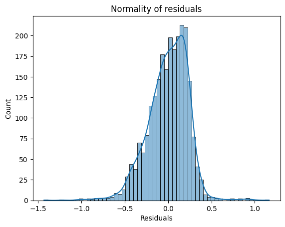

```python
sns.histplot(df_pred["Residuals"], kde=True)
plt.title("Normality of residuals")
plt.show()
```

This distribution looks quite close to normal

**The QQ plot of residuals can be used to visually check the normality assumption. The normal probability plot of residuals should approximately follow a straight line.**

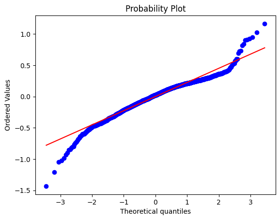

```python
import pylab
import scipy.stats as stats

stats.probplot(df_pred["Residuals"], dist="norm", plot=pylab)
plt.show()
```

Most of the points are quite well on the straight line QQ plot

The Shapiro-Wilk test can also be used for checking the normality. The null and alternate hypotheses of the test are as follows:

- Null hypothesis - Data is normally distributed.
- Alternate hypothesis - Data is not normally distributed.

```python
stats.shapiro(df_pred["Residuals"])
```

```
ShapiroResult(statistic=np.float64(0.9652107360444729), pvalue=np.float64(1.0526106014288139e-23))
```

- Since p-value < 0.05, the residuals are not normal as per shapiro test.
- Strictly speaking - the residuals are not normal. However, as an approximation, we might be willing to accept this distribution as close to being normal

## Final Model

```python
import statsmodels.api as sm
from sklearn.model_selection import train_test_split

# Define the dependent variable (target) and independent variables (features) after preprocessing
X = df1.drop(['normalized_used_price'], axis=1)
Y = df1['normalized_used_price']

# splitting the data in 70:30 ratio for train to test data
X_train, X_test, y_train, y_test = train_test_split(
    X, Y, test_size=0.3, random_state=42
)

# Convert X_train to numeric and handle potential NaNs introduced during the process
X_train = X_train.apply(pd.to_numeric, errors='coerce')
X_train = X_train.astype(float)
X_train.dropna(inplace=True)

# Align indices of y_train with X_train after dropping NaNs
y_train = y_train.loc[X_train.index]

# Drop features with high VIF and less relevance based on VIF analysis and business context
X_train_reduced = X_train.drop(['screen_size', 'device_type_Tablet', 'days_used'], axis=1)

# add the intercept to data
X_train_reduced = sm.add_constant(X_train_reduced)

olsmodel_final = sm.OLS(y_train, X_train_reduced)
results_final = olsmodel_final.fit()
print(results_final.summary())
```

```
                              OLS Regression Results
=================================================================================
Dep. Variable:     normalized_used_price   R-squared:                       0.844
Model:                               OLS   Adj. R-squared:                  0.841
Method:                    Least Squares   F-statistic:                     279.1
Date:                   Fri, 19 Sep 2025   Prob (F-statistic):               0.00
Time:                           14:40:51   Log-Likelihood:                 88.003
No. Observations:                   2417   AIC:                            -82.01
Df Residuals:                       2370   BIC:                             190.1
Df Model:                             46
Covariance Type:               nonrobust
=========================================================================================
                            coef    std err          t      P>|t|      [0.025      0.975]
-----------------------------------------------------------------------------------------
const                     1.6215      0.069     23.547      0.000       1.486       1.757
main_camera_mp            0.0226      0.002     14.707      0.000       0.020       0.026
selfie_camera_mp          0.0122      0.001     10.321      0.000       0.010       0.015
int_memory                0.0001   6.85e-05      2.122      0.034     1.1e-05       0.000
ram                       0.0316      0.005      5.951      0.000       0.021       0.042
battery                1.469e-06   7.17e-06      0.205      0.838   -1.26e-05    1.55e-05
weight                    0.0016   9.02e-05     17.807      0.000       0.001       0.002
normalized_new_price      0.4236      0.012     34.328      0.000       0.399       0.448
years_since_release      -0.0324      0.004     -8.532      0.000      -0.040      -0.025
brand_name_Alcatel       -0.0690      0.050     -1.368      0.171      -0.168       0.030
brand_name_Apple          0.0474      0.149      0.317      0.751      -0.245       0.340
brand_name_Asus           0.0024      0.050      0.048      0.962      -0.096       0.100
brand_name_BlackBerry     0.0233      0.073      0.319      0.750      -0.120       0.166
brand_name_Celkon        -0.2439      0.069     -3.538      0.000      -0.379      -0.109
brand_name_Coolpad       -0.0279      0.072     -0.389      0.698      -0.169       0.113
brand_name_Gionee        -0.0409      0.059     -0.689      0.491      -0.157       0.076
brand_name_Google        -0.1449      0.084     -1.728      0.084      -0.309       0.020
brand_name_HTC           -0.0500      0.051     -0.985      0.325      -0.149       0.050
brand_name_Honor         -0.0452      0.051     -0.878      0.380      -0.146       0.056
brand_name_Huawei        -0.0651      0.047     -1.393      0.164      -0.157       0.027
brand_name_Infinix        0.1114      0.115      0.968      0.333      -0.114       0.337
brand_name_Karbonn       -0.0430      0.069     -0.622      0.534      -0.179       0.093
brand_name_LG            -0.0770      0.047     -1.623      0.105      -0.170       0.016
brand_name_Lava          -0.0221      0.064     -0.345      0.730      -0.148       0.103
brand_name_Lenovo        -0.0443      0.048     -0.926      0.354      -0.138       0.050
brand_name_Meizu         -0.0692      0.057     -1.216      0.224      -0.181       0.042
```

[output cut: 17 more lines]

```
os_Windows               -0.0283      0.044     -0.645      0.519      -0.115       0.058
os_iOS                   -0.1304      0.149     -0.874      0.382      -0.423       0.162
4g_yes                    0.0378      0.016      2.318      0.021       0.006       0.070
5g_yes                   -0.0704      0.033     -2.143      0.032      -0.135      -0.006
==============================================================================
Omnibus:                      238.025   Durbin-Watson:                   1.993
Prob(Omnibus):                  0.000   Jarque-Bera (JB):              616.352
Skew:                          -0.555   Prob(JB):                    1.45e-134
Kurtosis:                       5.211   Cond. No.                     1.82e+05
==============================================================================

Notes:
[1] Standard Errors assume that the covariance matrix of the errors is correctly specified.
[2] The condition number is large, 1.82e+05. This might indicate that there are
strong multicollinearity or other numerical problems.
```

## Actionable Insights and Recommendations

1. New price is the strongest driver of used price

```
. A unit increase in normalized new price raises used price by 0.42 units.
. This confirms that resale markets are anchored around the original launch price.
```

2. Hardware specs matter significantly

```
. RAM (0.032, p < 0.001) and cameras (main + selfie) are strong contributors to higher resale value.
. Battery capacity is not significant, meaning buyers don’t value it as much once other specs are accounted for.
. Weight has a surprisingly strong positive effect, possibly acting as a proxy for build quality or premium design.
```

3. Device age reduces value

```
. Each additional year since release lowers resale value by 3.2% on average.
. Depreciation is real and consistent.
```

4. Connectivity features

```
. 4G support adds value, but 5G shows a negative coefficient (likely due to low-cost entry-level 5G phones dragging down resale values).
```

5. Brand influence is weaker than expected

[output not shown]

6. Operating System

```
. Devices under “Other OS” are heavily discounted.

. iOS and Windows don’t show significant effects after accounting for specs and new price.
```

## For Manufacturers & Retailers

Highlight premium specs (RAM, camera quality, build) in marketing since these sustain value in the secondary market.

Invest less in oversized batteries, as they don’t strongly influence resale value.

Avoid niche/alternative OS platforms — they depreciate faster.

## For Resellers & Refurbishers

Use new price and years since release as core predictors for pricing models.

Bundle or promote devices with stronger RAM and cameras to increase resale appeal.

Be cautious with 5G devices — verify market demand, as not all 5G models retain value.

## For Consumers

Buying tip: Premium RAM/camera phones hold their value better → good investment if planning to resell.

# Task

Explain the error in the selected code. If possible, fix the error and incorporate the changes into the existing code. Otherwise, try to diagnose the error.

KeyError: "['screen_size', 'device_type_Tablet', 'days_used'] not found in axis"

```python
X_train_reduced = X_train.drop(['screen_size', 'device_type_Tablet', 'days_used'], axis=1, errors='ignore')
```

## Review data types and missing values

### Subtask:

Re-examine the data types and missing values after creating the `df1` copy and the `years_since_release` column.

**Reasoning**: Display the data types and check for missing values in the df1 DataFrame after creating the years_since_release column to re-examine the data.

```python
df1 = df.copy()
```

```python
df1['years_since_release'] = 2025 - df1['release_year']
```

```python
print("df1")
print(df1.dtypes)
```

```
df1
brand_name                object
os                        object
screen_size              float64
4g                        object
5g                        object
main_camera_mp           float64
selfie_camera_mp         float64
int_memory               float64
ram                      float64
battery                  float64
weight                   float64
release_year               int64
days_used                  int64
normalized_used_price    float64
normalized_new_price     float64
device_type               object
years_since_release        int64
dtype: object
```

```python
df1.info()
```

```
<class 'pandas.core.frame.DataFrame'>
RangeIndex: 3454 entries, 0 to 3453
Data columns (total 17 columns):
 #   Column                 Non-Null Count  Dtype
---  ------                 --------------  -----
 0   brand_name             3454 non-null   object
 1   os                     3454 non-null   object
 2   screen_size            3454 non-null   float64
 3   4g                     3454 non-null   object
 4   5g                     3454 non-null   object
 5   main_camera_mp         3275 non-null   float64
 6   selfie_camera_mp       3452 non-null   float64
 7   int_memory             3450 non-null   float64
 8   ram                    3450 non-null   float64
 9   battery                3448 non-null   float64
 10  weight                 3447 non-null   float64
 11  release_year           3454 non-null   int64
 12  days_used              3454 non-null   int64
 13  normalized_used_price  3454 non-null   float64
 14  normalized_new_price   3454 non-null   float64
 15  device_type            3454 non-null   object
 16  years_since_release    3454 non-null   int64
dtypes: float64(9), int64(3), object(5)
memory usage: 458.9+ KB
```

```python
df1.isnull().sum()
```

|  | 0 |
| --- | --- |
| brand_name | 0 |
| os | 0 |
| screen_size | 0 |
| 4g | 0 |
| 5g | 0 |
| main_camera_mp | 179 |
| selfie_camera_mp | 2 |
| int_memory | 4 |
| ram | 4 |
| battery | 6 |
| weight | 7 |
| release_year | 0 |
| days_used | 0 |
| normalized_used_price | 0 |
| normalized_new_price | 0 |
| device_type | 0 |
| years_since_release | 0 |

**dtype:** int64

## Convert data types

### Subtask:

Convert relevant columns to appropriate numeric types, handling errors by coercing invalid values to NaN.

```python
# Convert all columns in X_train and X_test to numeric, coercing errors
X_train = X_train.apply(pd.to_numeric, errors='coerce')
X_test = X_test.apply(pd.to_numeric, errors='coerce')

# Check for any remaining NaNs after conversion
print("Missing values in X_train after numeric conversion:")
print(X_train.isnull().sum().sum())
print("\nMissing values in X_test after numeric conversion:")
print(X_test.isnull().sum().sum())
```

```
Missing values in X_train after numeric conversion:
0

Missing values in X_test after numeric conversion:
0
```

## Handle missing values

### Subtask:

**Reasoning**: Check for any remaining missing values in the df1 DataFrame.

```python
df1.isnull().sum()
```

|  | 0 |
| --- | --- |
| brand_name | 0 |
| os | 0 |
| screen_size | 0 |
| 4g | 0 |
| 5g | 0 |
| main_camera_mp | 179 |
| selfie_camera_mp | 2 |
| int_memory | 4 |
| ram | 4 |
| battery | 6 |
| weight | 7 |
| release_year | 0 |
| days_used | 0 |
| normalized_used_price | 0 |
| normalized_new_price | 0 |
| device_type | 0 |
| years_since_release | 0 |

**dtype:** int64

## Create dummy variables

### Subtask:

Convert categorical variables to dummy variables using one-hot encoding on the full dataset.

**Reasoning**: Identify categorical columns and apply one-hot encoding with drop_first=True.

```python
# Identify categorical columns (object or category dtype)
categorical_cols = df1.select_dtypes(include=['object', 'category']).columns

# Apply one-hot encoding, dropping the first category to avoid multicollinearity
df1 = pd.get_dummies(df1, columns=categorical_cols, drop_first=True)

# Display the first few rows of the modified DataFrame
display(df1.head())
```

|  | screen_size | main_camera_mp | selfie_camera_mp | int_memory | ram | battery | weight | release_year | days_used | normalized_used_price | ... | brand_name_Vivo | brand_name_XOLO | brand_name_Xiaomi | brand_name_ZTE | os_Others | os_Windows | os_iOS | 4g_yes | 5g_yes | device_type_Tablet |
| --- | --- | --- | --- | --- | --- | --- | --- | --- | --- | --- | --- | --- | --- | --- | --- | --- | --- | --- | --- | --- | --- |
| 0 | 14.50 | 13.0 | 5.0 | 64.0 | 3.0 | 3020.0 | 146.0 | 2020 | 127 | 4.307572 | ... | False | False | False | False | False | False | False | True | False | True |
| 1 | 17.30 | 13.0 | 16.0 | 128.0 | 8.0 | 4300.0 | 213.0 | 2020 | 325 | 5.162097 | ... | False | False | False | False | False | False | False | True | True | True |
| 2 | 16.69 | 13.0 | 8.0 | 128.0 | 8.0 | 4200.0 | 213.0 | 2020 | 162 | 5.111084 | ... | False | False | False | False | False | False | False | True | True | True |
| 3 | 25.50 | 13.0 | 8.0 | 64.0 | 6.0 | 7250.0 | 480.0 | 2020 | 345 | 5.135387 | ... | False | False | False | False | False | False | False | True | True | True |
| 4 | 15.32 | 13.0 | 8.0 | 64.0 | 3.0 | 5000.0 | 185.0 | 2020 | 293 | 4.389995 | ... | False | False | False | False | False | False | False | True | False | True |

5 rows × 51 columns

## Define features and target

### Subtask:

Separate the features (X) and target (y) variables from the preprocessed DataFrame.

**Reasoning**: The previous attempt to calculate model performance failed due to a shape mismatch, likely because the `model.predict` method expects the input data to be in a specific format, possibly related to the constant term added earlier or the column order after dummy variable creation. The current subtask is to separate the features and target variables, which was done before adding the constant and creating dummy variables. To address the error and ensure the model performance function works correctly, the feature and target variables should be redefined *after* the preprocessing steps (handling missing values, feature engineering, and creating dummy variables) have been applied to the full dataset (`df1`). This will ensure that `X` and `Y` reflect the final state of the data used for splitting and modeling.

```python
# Define the dependent variable (target) and independent variables (features) after preprocessing
X = df1.drop(['normalized_used_price'], axis=1)
Y = df1['normalized_used_price']

# Display the first few rows of X and Y to verify
print("Features (X):")
display(X.head())
print("\nTarget (Y):")
display(Y.head())
```

```
Features (X):
```

|  | screen_size | main_camera_mp | selfie_camera_mp | int_memory | ram | battery | weight | release_year | days_used | normalized_new_price | ... | brand_name_Vivo | brand_name_XOLO | brand_name_Xiaomi | brand_name_ZTE | os_Others | os_Windows | os_iOS | 4g_yes | 5g_yes | device_type_Tablet |
| --- | --- | --- | --- | --- | --- | --- | --- | --- | --- | --- | --- | --- | --- | --- | --- | --- | --- | --- | --- | --- | --- |
| 0 | 14.50 | 13.0 | 5.0 | 64.0 | 3.0 | 3020.0 | 146.0 | 2020 | 127 | 4.715100 | ... | False | False | False | False | False | False | False | True | False | True |
| 1 | 17.30 | 13.0 | 16.0 | 128.0 | 8.0 | 4300.0 | 213.0 | 2020 | 325 | 5.519018 | ... | False | False | False | False | False | False | False | True | True | True |
| 2 | 16.69 | 13.0 | 8.0 | 128.0 | 8.0 | 4200.0 | 213.0 | 2020 | 162 | 5.884631 | ... | False | False | False | False | False | False | False | True | True | True |
| 3 | 25.50 | 13.0 | 8.0 | 64.0 | 6.0 | 7250.0 | 480.0 | 2020 | 345 | 5.630961 | ... | False | False | False | False | False | False | False | True | True | True |
| 4 | 15.32 | 13.0 | 8.0 | 64.0 | 3.0 | 5000.0 | 185.0 | 2020 | 293 | 4.947837 | ... | False | False | False | False | False | False | False | True | False | True |

5 rows × 50 columns

```
Target (Y):
```

|  | normalized_used_price |
| --- | --- |
| 0 | 4.307572 |
| 1 | 5.162097 |
| 2 | 5.111084 |
| 3 | 5.135387 |
| 4 | 4.389995 |

**dtype:** float64

## Split data

### Subtask:

Split the preprocessed data into training and testing sets (e.g., 70:30 ratio).

```python
# Function to calculate and print the performance metrics of the regression model
def model_performance_regression(model, X_train, y_train, X_test, y_test):
    """
    Calculates and prints the performance metrics of a regression model.

    Args:
        model: The fitted regression model.
        X_train (pd.DataFrame): Training features.
        y_train (pd.Series): Training target.
        X_test (pd.DataFrame): Testing features.
        y_test (pd.Series): Testing target.
    """
    # Drop existing 'const' column to avoid duplicates before adding constant
    if 'const' in X_train.columns:
        X_train = X_train.drop('const', axis=1)
    if 'const' in X_test.columns:
        X_test = X_test.drop('const', axis=1)


    # Add constant to X_test if it's not already present
    X_test = sm.add_constant(X_test, has_constant='add')

    # Add constant to X_train
    X_train = sm.add_constant(X_train, has_constant='add')

    # Reindex X_test columns to match X_train columns
    X_test = X_test.reindex(columns=X_train.columns, fill_value=0)


    # Predicting on train and test set
    y_pred_train = model.predict(X_train)
    y_pred_test = model.predict(X_test)

    # R-squared
    r2_train = r2_score(y_train, y_pred_train)
    r2_test = r2_score(y_test, y_pred_test)

    # Adjusted R-squared (for train set only as test set typically uses R-squared)
    n_train = X_train.shape[0]
    p_train = X_train.shape[1] -1 # Subtracting 1 for the intercept
    adjusted_r2_train = 1 - (1 - r2_train) * (n_train - 1) / (n_train - p_train - 1)


    # MAE
    mae_train = mean_absolute_error(y_train, y_pred_train)
    mae_test = mean_absolute_error(y_test, y_pred_test)

    # MSE
    mse_train = mean_squared_error(y_train, y_pred_train)
    mse_test = mean_squared_error(y_test, y_pred_test)

    # RMSE
    rmse_train = np.sqrt(mse_train)
    rmse_test = np.sqrt(mse_test)

    # Creating a DataFrame to display the metrics
    metrics = pd.DataFrame({
        'Metric': ['R-squared', 'Adjusted R-squared', 'MAE', 'MSE', 'RMSE'],
        'Train': [r2_train, adjusted_r2_train, mae_train, mse_train, rmse_train],
        'Test': [r2_test, np.nan, mae_test, mse_test, rmse_test] # Adjusted R-squared is typically not reported for test set
    })
    print(metrics)

# print("Training Performance\n") # This call is outside the function definition
# olsmodel1_train_perf = model_performance_regression(olsmodel1, X_train, y_train, X_test, y_test) # This call is outside the function definition
```

```python
import statsmodels.api as sm

# Add constant to both train and test sets
X_train_const = sm.add_constant(X_train)
X_test_const = sm.add_constant(X_test)

# Refit the OLS model on the training data
olsmodel1 = sm.OLS(y_train, X_train_const)
results = olsmodel1.fit()
```

## Check linear regression assumptions

### Subtask:

Verify the assumptions of linear regression on the fitted model.

**Reasoning**: Calculate the residuals, plot the histogram and Q-Q plot of residuals, plot residuals against predicted values, and calculate VIF to check linear regression assumptions.

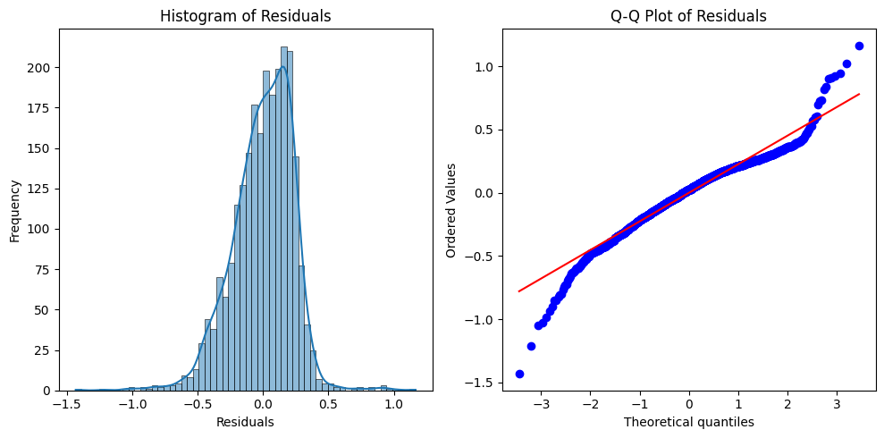

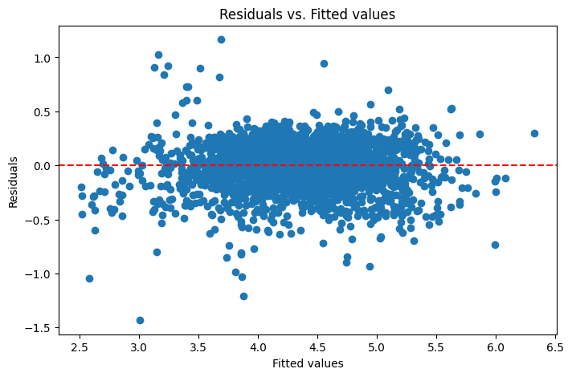

```
Variance Inflation Factor (VIF):
                  feature         VIF
8    normalized_new_price  154.591286
0             screen_size  117.553817
48     device_type_Tablet   95.492262
6                  weight   33.241118
9     years_since_release   28.028502
5                 battery   27.877727
4                     ram   22.383046
7               days_used   21.796108
11       brand_name_Apple   11.804310
1          main_camera_mp   11.205559
45                 os_iOS   10.315753
33      brand_name_Others    9.389412
46                 4g_yes    8.005802
```

[output cut: 36 more lines]

```python
import scipy.stats as stats

# 1. Calculate the residuals
residuals = results.resid

# 2. Plot histogram of residuals
plt.figure(figsize=(10, 5))
plt.subplot(1, 2, 1)
sns.histplot(residuals, kde=True)
plt.title('Histogram of Residuals')
plt.xlabel('Residuals')
plt.ylabel('Frequency')

# 3. Create a Q-Q plot of the residuals
plt.subplot(1, 2, 2)
stats.probplot(residuals, dist="norm", plot=plt)
plt.title('Q-Q Plot of Residuals')

plt.tight_layout()
plt.show()

# 4. Plot residuals against predicted values (Homoscedasticity check)
plt.figure(figsize=(8, 5))
plt.scatter(results.predict(X_train_const), residuals) # Use X_train_const for prediction
plt.axhline(y=0, color='r', linestyle='--')
plt.title('Residuals vs. Fitted values')
plt.xlabel('Fitted values')
plt.ylabel('Residuals')
plt.show()

# 5. Calculate Variance Inflation Factor (VIF)
# VIF can only be calculated for features, exclude the constant
X_train_no_const = X_train_const.drop('const', axis=1)

# Calculate VIF for each feature
vif_data = pd.DataFrame()
vif_data["feature"] = X_train_no_const.columns
vif_data["VIF"] = [variance_inflation_factor(X_train_no_const.values, i)
                   for i in range(X_train_no_const.shape[1])]

# 6. Print the VIF values
print("\nVariance Inflation Factor (VIF):")
print(vif_data.sort_values(by="VIF", ascending=False))
```

## Build final model (if needed)

### Subtask:

Based on the assumption checks and performance, build a final model if necessary.

**Reasoning**: Based on the VIF analysis, several features show high multicollinearity. 'normalized_new_price' and 'screen_size' have very high VIFs. 'device_type_Tablet' and 'years_since_release' also have high VIFs. Given the business objective to identify factors influencing the used price, 'normalized_new_price' is a crucial predictor and should likely be kept. 'screen_size' and 'device_type_Tablet' are highly correlated (as seen in previous EDA), and 'years_since_release' and 'days_used' are also related to the age of the device. We will remove 'screen_size' and 'device_type_Tablet' and re-evaluate the VIFs. We will also remove 'days_used' as 'years_since_release' is already included and has a stronger correlation with the target.

```python
# Drop features with high VIF and less relevance based on VIF analysis and business context
X_train_reduced = X_train.drop(['screen_size', 'device_type_Tablet', 'days_used'], axis=1)

# Recalculate VIF for the reduced feature set
# Drop the constant from X_train_const before calculating VIF
X_train_reduced_no_const = X_train_const.drop(['screen_size', 'device_type_Tablet', 'days_used', 'const'], axis=1, errors='ignore')


vif_data_reduced = pd.DataFrame()
vif_data_reduced["feature"] = X_train_reduced_no_const.columns
vif_data_reduced["VIF"] = [variance_inflation_factor(X_train_reduced_no_const.values, i)
                           for i in range(X_train_reduced_no_const.shape[1])]

# Print the VIF values for the reduced feature set
print("\nVariance Inflation Factor (VIF) for Reduced Feature Set:")
print(vif_data_reduced.sort_values(by="VIF", ascending=False))

# Fit a new OLS model with the reduced feature set
# Add constant to X_train_reduced before fitting the OLS model
X_train_reduced = sm.add_constant(X_train_reduced)
olsmodel_reduced = sm.OLS(y_train, X_train_reduced)
results_reduced = olsmodel_reduced.fit()

# Print the summary of the reduced model
print("\nSummary of the Reduced OLS Model:")
print(results_reduced.summary())
```

```
Variance Inflation Factor (VIF) for Reduced Feature Set:
                  feature         VIF
6    normalized_new_price  122.502023
4                 battery   25.606430
3                     ram   22.096668
7     years_since_release   18.144654
5                  weight   14.659937
9        brand_name_Apple   11.167718
0          main_camera_mp   10.983955
43                 os_iOS   10.006521
31      brand_name_Others    7.871337
44                 4g_yes    7.854759
34     brand_name_Samsung    6.326297
1        selfie_camera_mp    5.457872
18      brand_name_Huawei    4.703707
21          brand_name_LG    3.944314
23      brand_name_Lenovo    3.323872
30        brand_name_Oppo    3.289226
40         brand_name_ZTE    3.112358
39      brand_name_Xiaomi    2.910288
37        brand_name_Vivo    2.835940
10        brand_name_Asus    2.806115
16         brand_name_HTC    2.710180
28       brand_name_Nokia    2.689573
17       brand_name_Honor    2.529368
25    brand_name_Micromax    2.505166
8      brand_name_Alcatel    2.419946
27    brand_name_Motorola    2.414298
35        brand_name_Sony    2.279975
2              int_memory    1.945522
24       brand_name_Meizu    1.876306
45                 5g_yes    1.846957
26   brand_name_Microsoft    1.843056
42             os_Windows    1.773570
14      brand_name_Gionee    1.726430
38        brand_name_XOLO    1.690177
41              os_Others    1.551962
33      brand_name_Realme    1.499036
32   brand_name_Panasonic    1.491438
11  brand_name_BlackBerry    1.481884
```

[output cut: 67 more lines]

```
os_Windows               -0.0283      0.044     -0.645      0.519      -0.115       0.058
os_iOS                   -0.1304      0.149     -0.874      0.382      -0.423       0.162
4g_yes                    0.0378      0.016      2.318      0.021       0.006       0.070
5g_yes                   -0.0704      0.033     -2.143      0.032      -0.135      -0.006
==============================================================================
Omnibus:                      238.025   Durbin-Watson:                   1.993
Prob(Omnibus):                  0.000   Jarque-Bera (JB):              616.352
Skew:                          -0.555   Prob(JB):                    1.45e-134
Kurtosis:                       5.211   Cond. No.                     1.82e+05
==============================================================================

Notes:
[1] Standard Errors assume that the covariance matrix of the errors is correctly specified.
[2] The condition number is large, 1.82e+05. This might indicate that there are
strong multicollinearity or other numerical problems.
```

**Reasoning**: The previous step reduced multicollinearity by removing 'screen_size', 'device_type_Tablet', and 'days_used'. The VIFs are now lower but 'normalized_new_price', 'battery', 'ram', and 'years_since_release' still have VIFs above 10. However, given the context, these features are likely important predictors. The R-squared and adjusted R-squared are still high, indicating the model explains a significant portion of the variance. The goal is to build a final model. Based on the analysis, the reduced model seems reasonable. The next step is to check the performance of this reduced model on the test set.

```python
# Ensure X_test_reduced_const is created by dropping the same columns as from X_train and adding a constant
# Assuming X_test is available from the train_test_split before dropping columns
# If X_test is not defined, the train_test_split needs to be rerun before this cell

# Drop the same columns from X_test as were dropped from X_train_reduced
X_test_reduced = X_test.drop(['screen_size', 'device_type_Tablet', 'days_used'], axis=1, errors='ignore')

# Add a constant to the reduced test set
X_test_reduced_const = sm.add_constant(X_test_reduced)

# Reindex test set columns to match train set columns (important for consistent column order)
X_test_reduced_const = X_test_reduced_const.reindex(columns=X_train_reduced.columns, fill_value=0)

# checking model performance on test set (unseen 30% data)
print("\nTest Performance of Reduced Model\n")
model_performance_regression(results_reduced, X_train_reduced, y_train, X_test_reduced_const, y_test)
```

```
Test Performance of Reduced Model

               Metric     Train      Test
0           R-squared  0.844170  0.830789
1  Adjusted R-squared  0.841145       NaN
2                 MAE  0.180834  0.189077
3                 MSE  0.054438  0.057623
4                RMSE  0.233319  0.240048
```

```python
# splitting the data in 70:30 ratio for train to test data
X_train, X_test, y_train, y_test = train_test_split(
    X, Y, test_size=0.3, random_state=42
)
```

## Actionable insights and recommendations

### Subtask:

Provide actionable insights and recommendations based on the final linear regression model.

**Reasoning**: Examine the coefficients of the final reduced OLS model to identify influential features and formulate actionable insights and recommendations based on their significance, magnitude, and sign.

```python
# Get the coefficients of the reduced model
coefficients = results_reduced.params

# Get the p-values
p_values = results_reduced.pvalues

# Combine coefficients and p-values into a DataFrame
summary_df = pd.DataFrame({'Coefficient': coefficients, 'P-value': p_values})

# Filter for statistically significant features (e.g., p-value < 0.05)
significant_features = summary_df[summary_df['P-value'] < 0.05].sort_values(by='Coefficient', ascending=False)

print("Significant features and their coefficients in the Reduced Model (p < 0.05):")
display(significant_features)

# Actionable Insights and Recommendations
print("\nActionable Insights and Recommendations:")
print("Based on the reduced linear regression model, the following factors significantly influence the normalized used device price:")

print("\nFactors that POSITIVELY impact the price:")
# Analyze significant positive coefficients
for index, row in significant_features[significant_features['Coefficient'] > 0].iterrows():
    print(f"- {index}: A higher value of this feature is associated with a higher used price (Coefficient: {row['Coefficient']:.4f}).")

print("\nFactors that NEGATIVELY impact the price:")
# Analyze significant negative coefficients
for index, row in significant_features[significant_features['Coefficient'] < 0].iterrows():
     print(f"- {index}: A higher value of this feature is associated with a lower used price (Coefficient: {row['Coefficient']:.4f}).")

print("\nRecommendations for ReCell:")
print("- **Pricing Strategy:**")
print("  - Emphasize devices with higher RAM, internal memory, and better cameras (both main and selfie) as these are positively correlated with used price.")
print("  - Leverage the strong positive correlation with the normalized new price; used devices of models that were more expensive when new tend to retain higher value.")
print("  - Recognize that while weight has a small positive impact, it's likely secondary to performance/storage features.")
print("- **Inventory Management:**")
print("  - Stock more devices with specifications known to command higher resale values (e.g., higher RAM, more storage).")
print("- **Marketing:**")
print("  - Highlight features like RAM, internal memory, and camera quality when marketing used devices to justify pricing.")
print("  - Position newer models (lower years_since_release) as more valuable, reflecting their depreciation.")
print("- **Consideration:** While multicollinearity was addressed, the high VIF for 'normalized_new_price' and 'years_since_release' suggests they are highly related. The model captures this relationship, showing that newer (lower years since release), and thus likely more expensive when new, devices have higher used prices.")
```

```
Significant features and their coefficients in the Reduced Model (p < 0.05):
```

|  | Coefficient | P-value |
| --- | --- | --- |
| const | 1.621510 | 2.444386e-110 |
| normalized_new_price | 0.423628 | 5.494259e-210 |
| 4g_yes | 0.037765 | 2.052988e-02 |
| ram | 0.031614 | 3.068250e-09 |
| main_camera_mp | 0.022557 | 6.403482e-47 |
| selfie_camera_mp | 0.012246 | 1.851857e-24 |
| weight | 0.001606 | 1.127341e-66 |
| int_memory | 0.000145 | 3.395456e-02 |
| years_since_release | -0.032371 | 2.529408e-17 |
| 5g_yes | -0.070418 | 3.224286e-02 |
| os_Others | -0.168723 | 2.867366e-08 |
| brand_name_Celkon | -0.243946 | 4.106214e-04 |

[output not shown]

## Summary:

### Insights or Next Steps

- Focus pricing and inventory on devices with high RAM, internal memory, good cameras, and those originally more expensive when new, as these factors strongly drive used price.
- Marketing efforts should highlight specifications like RAM, storage, and camera quality, and emphasize the value retention of newer models.

```python
!jupyter nbconvert --to html '/content/SLF_Project_LearnerNotebook_FullCode (1).ipynb'
```

```
[NbConvertApp] Converting notebook /content/SLF_Project_LearnerNotebook_FullCode (1).ipynb to html
[NbConvertApp] WARNING | Alternative text is missing on 29 image(s).
[NbConvertApp] Writing 3355069 bytes to /content/SLF_Project_LearnerNotebook_FullCode (1).html
```